# Unsupervised Learning: Trade & Ahead

## Problem Statement

### Context

The stock market has consistently proven to be a good place to invest in and save for the future. There are a lot of compelling reasons to invest in stocks. It can help in fighting inflation, create wealth, and also provides some tax benefits. Good steady returns on investments over a long period of time can also grow a lot more than seems possible. Also, thanks to the power of compound interest, the earlier one starts investing, the larger the corpus one can have for retirement. Overall, investing in stocks can help meet life's financial aspirations.

It is important to maintain a diversified portfolio when investing in stocks in order to maximise earnings under any market condition. Having a diversified portfolio tends to yield higher returns and face lower risk by tempering potential losses when the market is down. It is often easy to get lost in a sea of financial metrics to analyze while determining the worth of a stock, and doing the same for a multitude of stocks to identify the right picks for an individual can be a tedious task. By doing a cluster analysis, one can identify stocks that exhibit similar characteristics and ones which exhibit minimum correlation. This will help investors better analyze stocks across different market segments and help protect against risks that could make the portfolio vulnerable to losses.

### Objective

Trade&Ahead is a financial consultancy firm who provide their customers with personalized investment strategies. They have hired you as a Data Scientist and provided you with data comprising stock price and some financial indicators for a few companies listed under the New York Stock Exchange. They have assigned you the tasks of analyzing the data, grouping the stocks based on the attributes provided, and sharing insights about the characteristics of each group.

### Data Dictionary

- Ticker Symbol: An abbreviation used to uniquely identify publicly traded shares of a particular stock on a particular stock market
- Company: Name of the company
- GICS Sector: The specific economic sector assigned to a company by the Global Industry Classification Standard (GICS) that best defines its business operations
- GICS Sub Industry: The specific sub-industry group assigned to a company by the Global Industry Classification Standard (GICS) that best defines its business operations
- Current Price: Current stock price in dollars
- Price Change: Percentage change in the stock price in 13 weeks
- Volatility: Standard deviation of the stock price over the past 13 weeks
- ROE: A measure of financial performance calculated by dividing net income by shareholders' equity (shareholders' equity is equal to a company's assets minus its debt)
- Cash Ratio: The ratio of a company's total reserves of cash and cash equivalents to its total current liabilities
- Net Cash Flow: The difference between a company's cash inflows and outflows (in dollars)
- Net Income: Revenues minus expenses, interest, and taxes (in dollars)
- Earnings Per Share: Company's net profit divided by the number of common shares it has outstanding (in dollars)
- Estimated Shares Outstanding: Company's stock currently held by all its shareholders
- P/E Ratio: Ratio of the company's current stock price to the earnings per share
- P/B Ratio: Ratio of the company's stock price per share by its book value per share (book value of a company is the net difference between that company's total assets and total liabilities)

### Problem Definition:

Trade & Ahead seeks to improve its client investment strategy services by identifying meaningful groupings of publicly traded companies based on financial performance indicators. The goal is to apply unsupervised learning techniques to cluster companies in a way that reveals investment patterns, informs portfolio recommendations, and supports risk-aligned advisory.

### Questions to be Answered:

- Can companies be grouped based on similar financial behavior using unsupervised learning?
- What are the key financial traits that differentiate investment-worthy clusters?
- How can these clusters support client segmentation and strategy personalization?

## Importing necessary libraries and data

```python
# Installing the libraries with the specified version.
!pip install scikit-learn==1.2.2 seaborn==0.13.1 matplotlib==3.7.1 numpy==1.25.2 pandas==1.5.3 yellowbrick==1.5 -q --user
```

**Note**: *After running the above cell, kindly restart the notebook kernel and run all cells sequentially from the start again.*

```python
# === Core Libraries ===
import numpy as np
import pandas as pd

# Display settings for DataFrames
pd.set_option("display.max_columns", None)
pd.set_option("display.max_rows", 200)

# === Visualization Libraries ===
import matplotlib.pyplot as plt
import seaborn as sns
sns.set_theme(style='darkgrid')

# === Utility ===
import warnings
warnings.filterwarnings("ignore")

# === Statistical Tools ===
from scipy.stats import zscore

# === Clustering Tools ===
from sklearn.cluster import KMeans, AgglomerativeClustering
from sklearn.metrics import silhouette_samples, silhouette_score
from scipy.cluster.hierarchy import dendrogram, linkage, fcluster

# === Dimensionality Reduction ===
from sklearn.decomposition import PCA
from sklearn.manifold import TSNE
```

# Loading the dataset

```python
# Load dataset from colab drive
from google.colab import drive
drive.mount('/content/drive')
```

```python
# Read the csv
data = pd.read_csv('/content/drive/MyDrive/Colab Notebooks/Data/stock_data.csv')
```

```python
# Make copy of the dataframe
df = data.copy()
```

# Data Overview

- Observations
- Sanity checks

```python
# Data overview
data_overview = {
    "Shape": df.shape,
    "Columns": df.columns.tolist(),
    "Data Types": df.dtypes,
    "Missing Values": df.isnull().sum(),
    "Summary Statistics": df.describe(include='all')
}

# Display results
data_overview
```

```
{'Shape': (340, 15),
 'Columns': ['Ticker Symbol',
  'Security',
  'GICS Sector',
  'GICS Sub Industry',
  'Current Price',
  'Price Change',
  'Volatility',
  'ROE',
  'Cash Ratio',
  'Net Cash Flow',
  'Net Income',
  'Earnings Per Share',
  'Estimated Shares Outstanding',
  'P/E Ratio',
  'P/B Ratio'],
 'Data Types': Ticker Symbol                    object
 Security                         object
 GICS Sector                      object
 GICS Sub Industry                object
 Current Price                   float64
 Price Change                    float64
 Volatility                      float64
 ROE                               int64
 Cash Ratio                        int64
 Net Cash Flow                     int64
 Net Income                        int64
 Earnings Per Share              float64
 Estimated Shares Outstanding    float64
 P/E Ratio                       float64
 P/B Ratio                       float64
 dtype: object,
 'Missing Values': Ticker Symbol                   0
 Security                        0
 GICS Sector                     0
 GICS Sub Industry               0
 Current Price                   0
 Price Change                    0
 Volatility                      0
 ROE                             0
```

[output cut: 57 more lines]

```
 75%               4.620000                  5.731175e+08   31.764755
 max              50.090000                  6.159292e+09  528.039074

          P/B Ratio
 count   340.000000
 unique         NaN
 top            NaN
 freq           NaN
 mean     -1.718249
 std      13.966912
 min     -76.119077
 25%      -4.352056
 50%      -1.067170
 75%       3.917066
 max     129.064585  }
```

Key Observations/Insights:

**Dataset Dimensions:**

- Rows 340; Columns 15

**Key Columns:**

- Categorical: Ticker Symbol, Security, GICS Sector, GICS Sub Industry
  - *Appears "Company" is misslabeled as "Security".*
- Numerical: Current Price, Price Change, Volatility, ROE, Cash Ratio, Net Cash Flow, Net Income, Earnings Per Share, Estimated Shares Outstanding, P/E Ratio, P/B Ratio

**Missing Values:**

- There appears to be no missing values across all columns.

**Numerical Summary (Selected Stats):**

- Current Price: Mean: 80.86; Range: 4.5 to 1274.95
- Price Change: Mean: 4.08; Range: -47.13 to 55.05
- Volatility: Mean: 1.53; Max: 4.58
- ROE (Return on Equity): Mean: 39.60; Max: 917
  - A value of 917% means the company is earning $9.17 for every $1 of equity, which is extremely high, It might be legit, but it’s unusual and possibly skews summary stats or modeling outcomes.*
- P/E Ratio: Mean: 32.61; Max: 528.04
- P/B Ratio: Mean: -1.71
  - *Some companies have negative book values, which leads to negative P/B.*

### Data Background and Contents:

The dataset contains stock and financial performance metrics for 340 companies listed on the New York Stock Exchange. Key features include:

- **Price & Volatility**: Current Price, Price Change %, and Price Volatility
- **Profitability Metrics**: ROE, Net Income, Earnings Per Share
- **Liquidity & Value**: Cash Ratio, Net Cash Flow, P/E Ratio, P/B Ratio
- **Categoricals**: Sector, Sub-Industry, Ticker Symbol

This rich mix of numerical and categorical attributes enables a holistic clustering approach that balances return potential, risk, and sector context.

### Convert object type to category type Before EDA (bearing in mind the end goal, clustering)

Reasons:

- Converting them to category will reduce memory usage, which is helpful to scale or run group operations.
- While clustering typically uses numerical inputs, having clear, clean categorical columns helps guide feature engineering (e.g., encoding sector info) & segment results (such as, "cluster 1 = mostly Financials")

```python
# Convert selected object columns to category
categorical_cols = ['Ticker Symbol', 'Security', 'GICS Sector', 'GICS Sub Industry']
df[categorical_cols] = df[categorical_cols].astype('category')

# Check the updated data types
updated_dtypes = df.dtypes[categorical_cols]
updated_dtypes
```

|  | 0 |
| --- | --- |
| Ticker Symbol | category |
| Security | category |
| GICS Sector | category |
| GICS Sub Industry | category |

**dtype:** object

Observations:

- Selected columns have been successfully converted to category

# Exploratory Data Analysis (EDA)

### **Note**: Only the key observations from EDA and outlined questions will be covered here, with focus on the model building aspects. A detailed EDA can be found in the Appendix A.

Questions:

- What does the distribution of stock prices look like?
- The stocks of which economic sector have seen the maximum price increase on average?
- How are the different variables correlated with each other?
- Cash ratio provides a measure of a company's ability to cover its short-term obligations using only cash and cash equivalents. How does the average cash ratio vary across economic sectors?
- P/E ratios can help determine the relative value of a company's shares as they signify the amount of money an investor is willing to invest in a single share of a company per dollar of its earnings. How does the P/E ratio vary, on average, across economic sectors?

### 1. What does the distribution of stock prices look like?

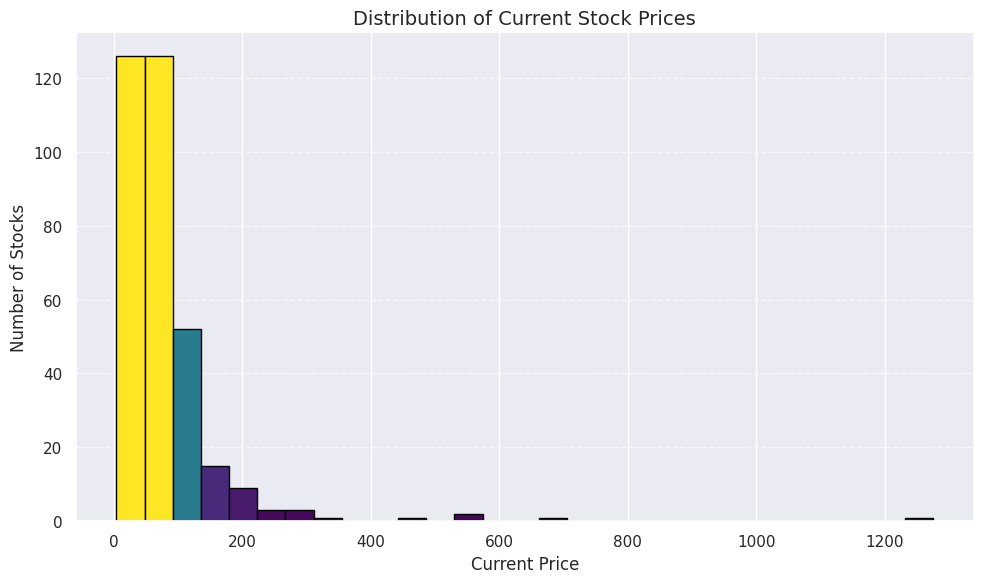

```
{'Min Price': 4.5,
 'Max Price': 1274.949951,
 'Median Price': 59.705,
 'Mean Price': 80.86234477216765,
 '75th Percentile': 92.88000124999999,
 '90th Percentile': 137.38600040000003}
```

```python
# Define bin edges
bins = np.linspace(df['Current Price'].min(), df['Current Price'].max(), 30)

# Create histogram with color and labels
plt.figure(figsize=(10, 6));
n, bins, patches = plt.hist(df['Current Price'], bins=bins, edgecolor='black')

# Color bins by height (darker = more stocks)
for count, patch in zip(n, patches):
    plt.setp(patch, 'facecolor', plt.cm.viridis(count / max(n)))

# Labels and styling
plt.title('Distribution of Current Stock Prices', fontsize=14)
plt.xlabel('Current Price', fontsize=12)
plt.ylabel('Number of Stocks', fontsize=12)
plt.grid(axis='y', linestyle='--', alpha=0.7)
plt.tight_layout()
plt.show()

# Generate textual insights
price_stats = {
    "Min Price": df['Current Price'].min(),
    "Max Price": df['Current Price'].max(),
    "Median Price": df['Current Price'].median(),
    "Mean Price": df['Current Price'].mean(),
    "75th Percentile": df['Current Price'].quantile(0.75),
    "90th Percentile": df['Current Price'].quantile(0.90)
}

price_stats
```

Observations/Insights:

- The histogram shows a right-skewed distribution with most stock prices clustered at the lower end, with observed key statistics.
- Most stocks are priced below $100 The median is $59.71, indicating that half of the stocks are priced below this value. About 75% of stocks are below $92.88, suggesting a concentration in the low to mid price range.
- Right-skewed distribution: A small number of very high-priced stocks up to $1,274.95 pull the mean $80.86 above the median. These outliers could be large-cap or premium growth stocks.
  - *Outlier analysis might be needed: will consider log-transforming prices or analyzing separately to avoid distortion in clustering or modeling.*

### 2. The stocks of which economic sector have seen the maximum price increase on average?

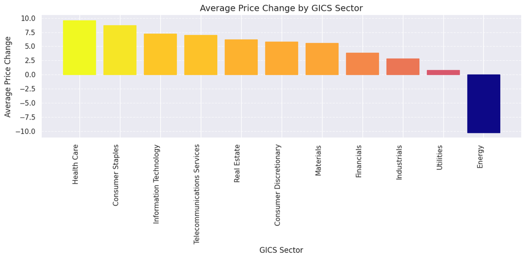

```
('Health Care', 9.585651574425)
```

```python
# Group by GICS Sector and calculate average price change
sector_price_change = df.groupby('GICS Sector')['Price Change'].mean().sort_values(ascending=False)

# Plotting the average price change by sector with colored bars
plt.figure(figsize=(12, 6));
bars = plt.bar(sector_price_change.index, sector_price_change.values, edgecolor='black')

# Color bars by value intensity using colormap
for bar, value in zip(bars, sector_price_change.values):
    bar.set_color(plt.cm.plasma((value - min(sector_price_change)) / (max(sector_price_change) - min(sector_price_change))))

# Add labels and rotate x-axis
plt.title('Average Price Change by GICS Sector', fontsize=14)
plt.xlabel('GICS Sector', fontsize=12)
plt.ylabel('Average Price Change', fontsize=12)
plt.xticks(rotation=90, ha='right')
plt.grid(axis='y', linestyle='--', alpha=0.7)
plt.tight_layout()
plt.show()

# Identify top performing sector
top_sector = sector_price_change.idxmax()
top_value = sector_price_change.max()

top_sector, top_value
```

Observations/Insights:

- The bar chart visualizes the average price change across all economic sectors, with color intensity reflecting the magnitude of the increase.
- **Health Care** stocks have seen the **highest average price increase**, with an average gain of ~9.59 units. This indicates strong positive momentum in the Health Care sector over the period captured in the dataset.
- Some sectors have modest or even negative average price changes, suggesting mixed performance across industries.

### 3. How are the different variables correlated with each other?

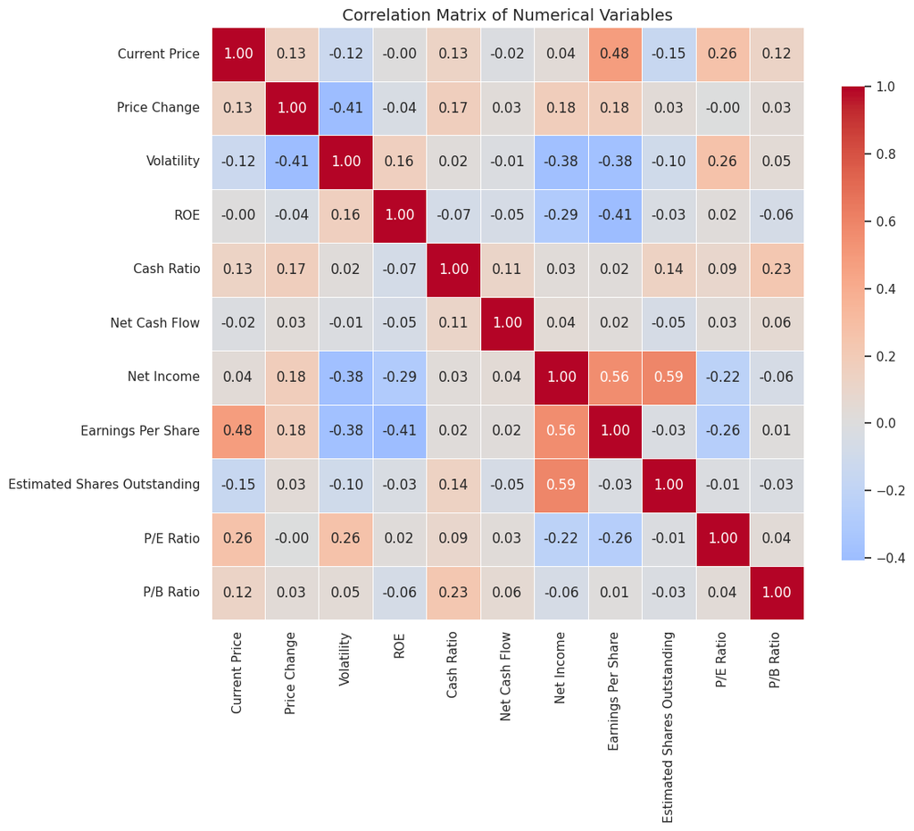

```
(Volatility  Price Change   -0.408281
 dtype: float64,
 Estimated Shares Outstanding  Net Income    0.58931
 dtype: float64)
```

```python
# Select only numerical columns for correlation analysis
numerical_df = df.select_dtypes(include=['number'])

# Compute the correlation matrix
corr_matrix = numerical_df.corr()

# Plot the correlation heatmap
plt.figure(figsize=(12, 10));
sns.heatmap(corr_matrix, annot=True, fmt=".2f", cmap='coolwarm', center=0, square=True,
            linewidths=0.5, cbar_kws={"shrink": .8})
plt.title('Correlation Matrix of Numerical Variables', fontsize=14)
plt.tight_layout()
plt.show()

# Identify the strongest positive and negative correlations (excluding self-correlations)
corr_unstacked = corr_matrix.unstack().sort_values()
strongest_negative = corr_unstacked[corr_unstacked < 1].head(1)
strongest_positive = corr_unstacked[corr_unstacked < 1].tail(1)

strongest_negative, strongest_positive
```

Observations/Insights:

Strongest Negative Correlation:

- Volatility vs. Price Change −0.41
  - Indicates that stocks with higher volatility tend to have lower price increases.
  - Suggests a potential risk-return tradeoff where more volatile stocks underperform on price movement in this sample.

Strongest Positive Correlation:

**Suggested Key Indicators Based on Heatmap:**

- Earnings Per Share, it captures performance, links to valuation
- P/E Ratio, key market sentiment metric
- ROE for profitability & efficiency
- Volatility, risk segmentation
- Price Change, shows recent market momentum

### 4. Cash ratio provides a measure of a company's ability to cover its short-term obligations using only cash and cash equivalents. How does the average cash ratio vary across economic sectors?

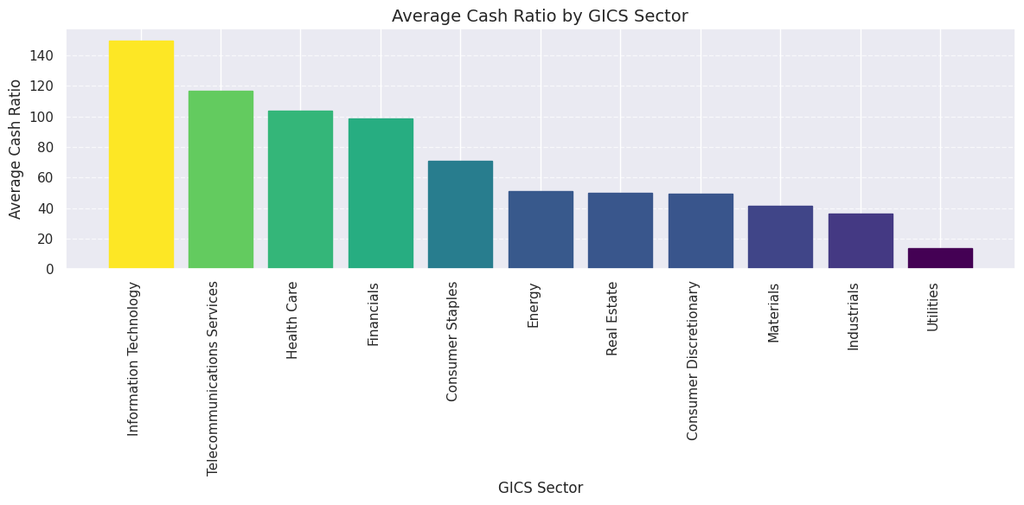

```
(('Information Technology', 149.8181818181818), ('Utilities', 13.625))
```

```python
# Group by GICS Sector and calculate the average Cash Ratio
sector_cash_ratio = df.groupby('GICS Sector')['Cash Ratio'].mean().sort_values(ascending=False)

# Plotting the average Cash Ratio by sector
plt.figure(figsize=(12, 6));
bars = plt.bar(sector_cash_ratio.index, sector_cash_ratio.values, edgecolor='black')

# Apply colormap ('viridis')
for bar, value in zip(bars, sector_cash_ratio.values):
    bar.set_color(plt.cm.viridis((value - min(sector_cash_ratio)) / (max(sector_cash_ratio) - min(sector_cash_ratio))))

# Labels and styling
plt.title('Average Cash Ratio by GICS Sector', fontsize=14)
plt.xlabel('GICS Sector', fontsize=12)
plt.ylabel('Average Cash Ratio', fontsize=12)
plt.xticks(rotation=90, ha='right')
plt.grid(axis='y', linestyle='--', alpha=0.7)
plt.tight_layout()
plt.show()

# Return the sector with the highest and lowest average cash ratios
highest_cash_sector = sector_cash_ratio.idxmax(), sector_cash_ratio.max()
lowest_cash_sector = sector_cash_ratio.idxmin(), sector_cash_ratio.min()

highest_cash_sector, lowest_cash_sector
```

Observations/Insights:

### 5. P/E ratios can help determine the relative value of a company's shares as they signify the amount of money an investor is willing to invest in a single share of a company per dollar of its earnings. How does the P/E ratio vary, on average, across economic sectors?

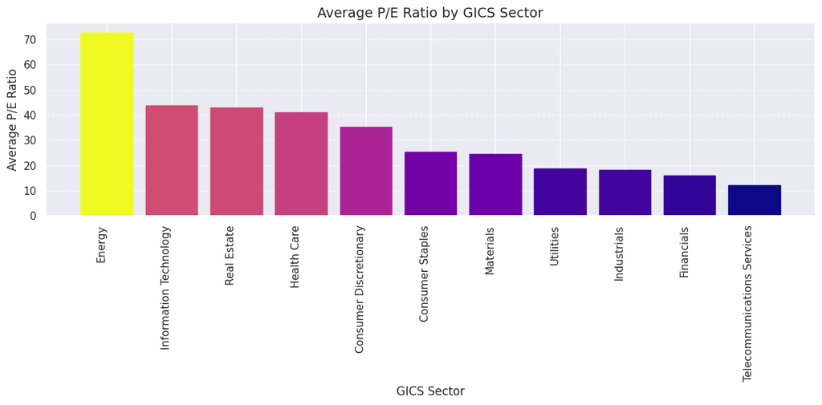

```
(('Energy', 72.8977086201), ('Telecommunications Services', 12.2225778534))
```

```python
# Group by GICS Sector and calculate the average P/E Ratio
sector_pe_ratio = df.groupby('GICS Sector')['P/E Ratio'].mean().sort_values(ascending=False)

# Plotting the average P/E Ratio
plt.figure(figsize=(12, 6));
bars = plt.bar(sector_pe_ratio.index, sector_pe_ratio.values, edgecolor='black')

# Apply colors using the 'plasma' colormap for strong contrast
for bar, value in zip(bars, sector_pe_ratio.values):
    bar.set_color(plt.cm.plasma((value - min(sector_pe_ratio)) / (max(sector_pe_ratio) - min(sector_pe_ratio))))

# Labels and styling
plt.title('Average P/E Ratio by GICS Sector', fontsize=14)
plt.xlabel('GICS Sector', fontsize=12)
plt.ylabel('Average P/E Ratio', fontsize=12)
plt.xticks(rotation=90, ha='right')
plt.grid(axis='y', linestyle='--', alpha=0.7)
plt.tight_layout()
plt.show()

# Return the sector with the highest and lowest average P/E ratios
highest_pe_sector = sector_pe_ratio.idxmax(), sector_pe_ratio.max()
lowest_pe_sector = sector_pe_ratio.idxmin(), sector_pe_ratio.min()

highest_pe_sector, lowest_pe_sector
```

Observations/Insights:

- As observed, highest & lowest P/E ratio by GICS sector are Energy & Telecommunications Services, respectively.
- Energy 72.90, this high P/E could reflect recent earnings volatility in the sector — possibly due to:
  - Recovery from losses
  - Temporarily low earnings
  - Investor speculation on future growth
- *High P/E in Energy is atypical, so it’s worth checking if it's driven by a few extreme values.*
- Telecommunications Services 12.22, suggests low market growth expectations or mature, stable earnings. Investors are paying less per $1 of earnings, potentially signaling undervaluation or slow growth.
- Wide range in P/E ratios shows how differently the market values earnings across sectors.
- Consumer Discretionary and Information Technology may also show elevated P/E due to future growth expectations.
- Sectors like Utilities and Telecom often maintain low, stable P/E ratios.

### Key Analysis EDA:

```python
# Sector Profile Summary Table
sector_profile = df.groupby('GICS Sector').agg({
    'Current Price': 'median',
    'Price Change': 'mean',
    'Volatility': 'mean',
    'ROE': 'mean',
    'P/E Ratio': 'mean',
    'P/B Ratio': 'mean'
}).sort_values(by='Price Change', ascending=False)

# Display summary
sector_profile
```

| GICS Sector | Current Price | Price Change | Volatility | ROE | P/E Ratio | P/B Ratio |
| --- | --- | --- | --- | --- | --- | --- |
| Health Care | 101.889999 | 9.585652 | 1.541023 | 27.775000 | 41.135272 | 0.068869 |
| Consumer Staples | 78.949997 | 8.684750 | 1.152675 | 89.421053 | 25.521195 | -4.554003 |
| Information Technology | 52.630001 | 7.217476 | 1.659801 | 21.787879 | 43.782546 | 6.377128 |
| Telecommunications Services | 34.410000 | 6.956980 | 1.341612 | 32.600000 | 12.222578 | -11.009858 |
| Real Estate | 80.690002 | 6.205548 | 1.206053 | 12.444444 | 43.065585 | -3.003320 |
| Consumer Discretionary | 67.200001 | 5.846093 | 1.595478 | 44.900000 | 35.211613 | -8.253543 |
| Materials | 67.055000 | 5.589738 | 1.816726 | 33.000000 | 24.585352 | 0.723103 |
| Financials | 54.360001 | 3.865406 | 1.267255 | 26.285714 | 16.023151 | -4.270505 |
| Industrials | 61.310001 | 2.833127 | 1.416989 | 50.150943 | 18.259380 | -0.979266 |
| Utilities | 52.250000 | 0.803657 | 1.118018 | 9.875000 | 18.719412 | -3.087350 |
| Energy | 39.255001 | -10.228289 | 2.568777 | 93.200000 | 72.897709 | 2.539738 |

Observations/Insights by Metric:

**Price Change (Performance Indicator)**

Top Gainers:

- Health Care (+9.59%)
- Consumer Staples (+8.68%)
- Information Technology (+7.22%)

Underperformer:

- Energy (-10.23%) – major outlier, possibly due to post-peak corrections or volatility in oil prices.

**Volatility (Risk Indicator)**

Most Volatile:

- Energy (2.57) and Materials (1.82). High risk-reward sectors.

Least Volatile:

- Consumer Staples (1.15) and Utilities (1.12), defensive sectors, more stable in market downturns.

**ROE (Profitability Indicator)**

High ROE:

- Energy (93%) and Consumer Staples (89%)
- *Could be inflated by small equity bases — needs deeper review.*

Low ROE:

- Utilities (9.9%) and Real Estate (12.4%) – suggests lower efficiency or capital-intensive models.

**P/E Ratio (Valuation Indicator)**

Highest Valuation:

Lowest Valuation:

**P/B Ratio (Value Relative to Book Value)**

Stocks can be grouped based on profiles like:

- Growth sectors: Health Care, IT
- Defensive sectors: Utilities, Staples
- Undervalued candidates: Telecom, Industrials
- High-risk, high-ROE: Energy, Consumer Discretionary

# Overall Insights Based on EDA:

# Data Preprocessing

- Drop unique identifiers
- Outlier check & treatment (if needed)
- Duplicate value check
- Missing value review/inputation
- Feature engineering (if needed)
- Any other preprocessing steps (if needed)
  - Log transformation (for skewed features)
  - Feature scaling/normalization (apply to all usable features)

### Dropping Unique Identifiers

```python
# Drop 'Ticker Symbol' and 'Security' (otherwise should be 'Company') columns because:
# - These are identifier fields, not numerical or categorical features with analytical value.
# - They do not contribute to patterns, clusters, or relationships between financial traits.
# - Including them in modeling or visualizations can cause noise or overfitting.

df.drop(columns=['Ticker Symbol', 'Security'], inplace=True)
```

Observation/Insights:

- Both 'Ticker Symbol' and 'Security' dropped during preprocessing as they serve only as unique identifiers. They do not contain predictive or descriptive power for clustering, EDA, or modeling. Keeping them may interfere with analysis by introducing high-cardinality, non-informative dimensions.

### Outlier Detection & Treatment:

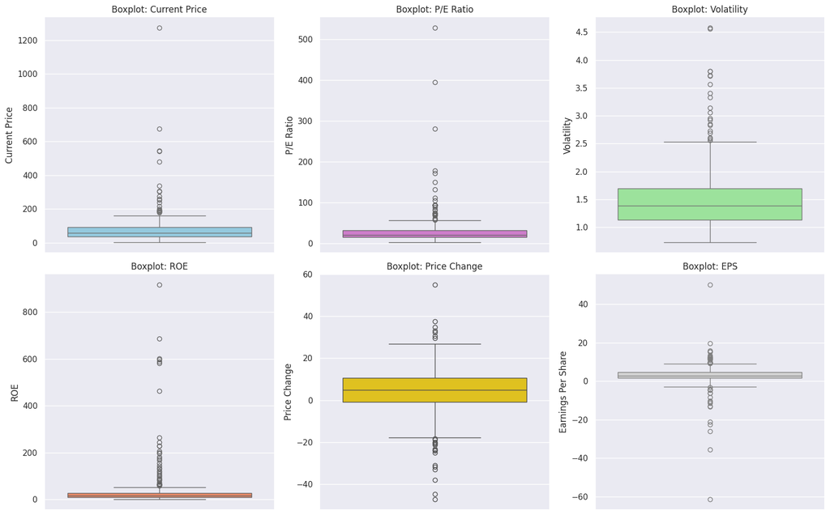

```python
# Outlier Detection Analysis
# Boxplots to detect if outliers exist in select key variables

fig, axes = plt.subplots(2, 3, figsize=(16, 10));
sns.boxplot(data=df, y='Current Price', ax=axes[0, 0], color='skyblue')
axes[0, 0].set_title('Boxplot: Current Price')

sns.boxplot(data=df, y='P/E Ratio', ax=axes[0, 1], color='orchid')
axes[0, 1].set_title('Boxplot: P/E Ratio')

sns.boxplot(data=df, y='Volatility', ax=axes[0, 2], color='lightgreen')
axes[0, 2].set_title('Boxplot: Volatility')

sns.boxplot(data=df, y='ROE', ax=axes[1, 0], color='coral')
axes[1, 0].set_title('Boxplot: ROE')

sns.boxplot(data=df, y='Price Change', ax=axes[1, 1], color='gold')
axes[1, 1].set_title('Boxplot: Price Change')

sns.boxplot(data=df, y='Earnings Per Share', ax=axes[1, 2], color='lightgrey')
axes[1, 2].set_title('Boxplot: EPS')

plt.tight_layout()
plt.show()
```

Observations/Insights:

- Current Price, P/E, and ROE all show significant right-skew and extreme values.
- Volatility has a relatively narrower range, but still varies by stock.
- EPS and Price Change have visible outliers which could distort averages and clustering.
  - These aid in deciding which features need transformation, scaling, or capping before modeling.

```python
# Outlier Treatment Analysis
from scipy.stats.mstats import winsorize

# Define features to cap based on boxplot insights
features_to_winsorize = [
    'Current Price',
    'Price Change',
    'Volatility',
    'ROE',
    'P/E Ratio',
    'Earnings Per Share'
]

# Apply winsorization (caps lowest and highest 1% of values for each feature)
df_winsorized = df.copy()
for col in features_to_winsorize:
    df_winsorized[col] = winsorize(df_winsorized[col], limits=[0.01, 0.01])

# Compare summary statistics before and after winsorization for validation
before_after_summary = pd.DataFrame({
    'Original Min': df[features_to_winsorize].min(),
    'Original Max': df[features_to_winsorize].max(),
    'Winsorized Min': df_winsorized[features_to_winsorize].min(),
    'Winsorized Max': df_winsorized[features_to_winsorize].max()
})

# Display
before_after_summary
```

|  | Original Min | Original Max | Winsorized Min | Winsorized Max |
| --- | --- | --- | --- | --- |
| Current Price | 4.500000 | 1274.949951 | 7.110000 | 542.869995 |
| Price Change | -47.129693 | 55.051683 | -33.131268 | 33.177346 |
| Volatility | 0.733163 | 4.580042 | 0.826408 | 3.794783 |
| ROE | 1.000000 | 917.000000 | 2.000000 | 596.000000 |
| P/E Ratio | 2.935451 | 528.039074 | 5.566284 | 178.451613 |
| Earnings Per Share | -61.200000 | 50.090000 | -22.430000 | 15.380000 |

Observations:

- Current price winsorized range means very high-priced outliers capped
- Price change winsorized range indicates volatile swings softened
- Volatility winsorized range shows removed extreme risk profiles
- ROE winsorized range indicates super-high ROEs capped, but still wide range
- P/E ratio winsorized range show that bubble-like valuations toned down
- EPS new range is more representative of the bulk of the data, making it more suitable for clustering, scaling, and correlation analysis — without being skewed by a few extreme values.

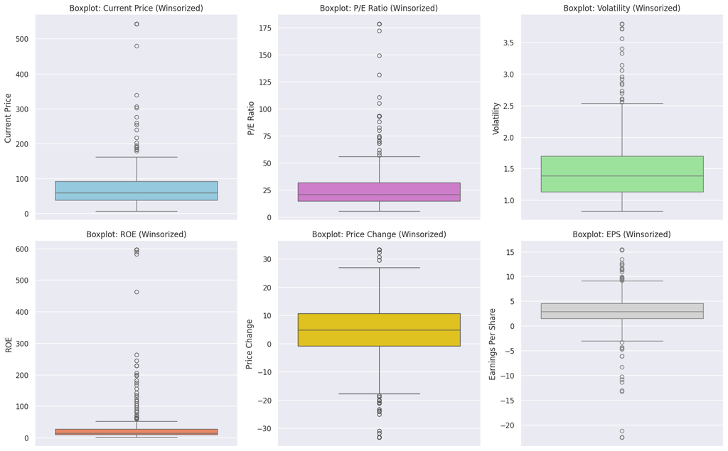

```python
# Visualize after Outliet Treatment
fig, axes = plt.subplots(2, 3, figsize=(16, 10));
sns.boxplot(data=df_winsorized, y='Current Price', ax=axes[0, 0], color='skyblue')
axes[0, 0].set_title('Boxplot: Current Price (Winsorized)')

sns.boxplot(data=df_winsorized, y='P/E Ratio', ax=axes[0, 1], color='orchid')
axes[0, 1].set_title('Boxplot: P/E Ratio (Winsorized)')

sns.boxplot(data=df_winsorized, y='Volatility', ax=axes[0, 2], color='lightgreen')
axes[0, 2].set_title('Boxplot: Volatility (Winsorized)')

sns.boxplot(data=df_winsorized, y='ROE', ax=axes[1, 0], color='coral')
axes[1, 0].set_title('Boxplot: ROE (Winsorized)')

sns.boxplot(data=df_winsorized, y='Price Change', ax=axes[1, 1], color='gold')
axes[1, 1].set_title('Boxplot: Price Change (Winsorized)')

sns.boxplot(data=df_winsorized, y='Earnings Per Share', ax=axes[1, 2], color='lightgrey')
axes[1, 2].set_title('Boxplot: EPS (Winsorized)')

plt.tight_layout()
plt.show()
```

Observations:

- Visuals indicate improvements as noted in before_after_summary stats

### Missing Value Review (post transformation): but it’s best practice to check again, especially after manipulating data.

```python
# Check for missing values in the winsorized dataset
missing_values = df_winsorized.isnull().sum()
missing_values = missing_values[missing_values > 0]  # Filter only features with missing values

missing_values
```

|  | 0 |
| --- | --- |

**dtype:** int64

Observations:

- No missing values detected in the dataset — including after Winsorization, dataset is clean and ready

### Feature Engineering & New Feature Creation:

Bearing in mind the task (grouping & segmentation),

- *Will create new features -*
  - *Market Cap = EPS × Shares Outstanding, Proxy for company size*
  - *Valuation Score = P/E × P/B Composite valuation signal*

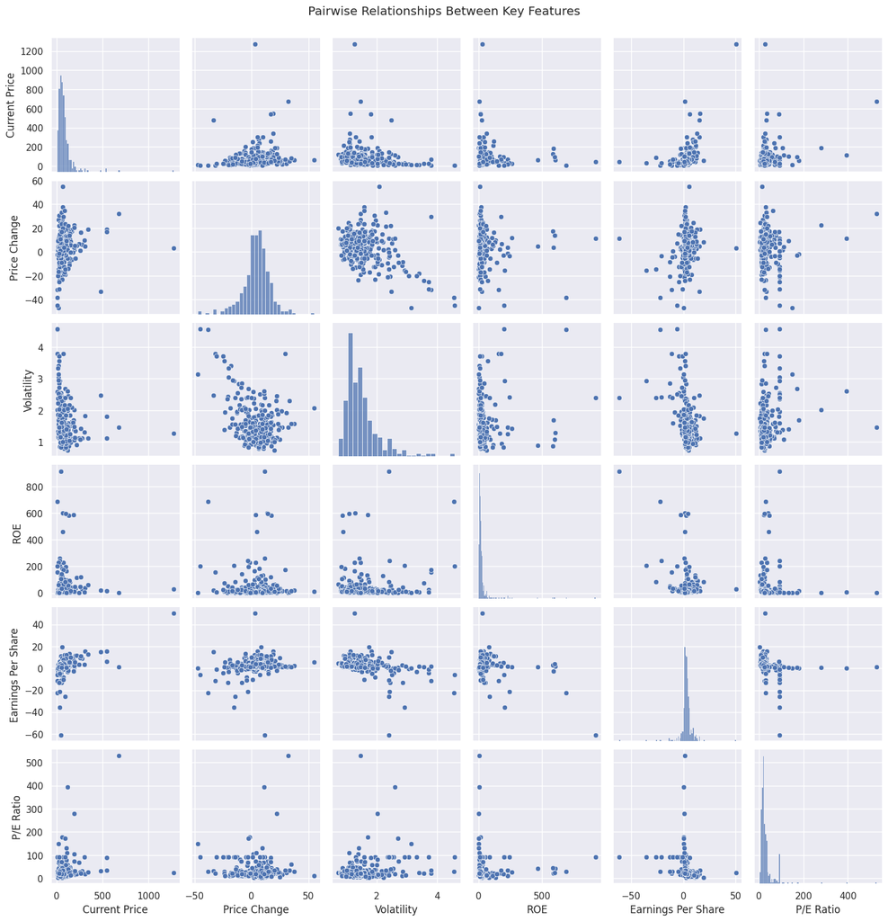

```python
# Feature relationships for clustering (pairwise plot of key indicators)
selected_features = df[['Current Price', 'Price Change', 'Volatility', 'ROE', 'Earnings Per Share', 'P/E Ratio']]
sns.pairplot(selected_features)
plt.suptitle('Pairwise Relationships Between Key Features', y=1.02)
plt.show()
```

Key Observations Feature Relationships (Pairwise Plots):

```python
# Create engineered features
df['Market Cap'] = df['Earnings Per Share'] * df['Estimated Shares Outstanding']
df['Valuation Score'] = df['P/E Ratio'] * df['P/B Ratio']

# Display new features
df[['Earnings Per Share', 'Estimated Shares Outstanding', 'Market Cap',
    'P/E Ratio', 'P/B Ratio', 'Valuation Score']].head(5)
```

|  | Earnings Per Share | Estimated Shares Outstanding | Market Cap | P/E Ratio | P/B Ratio | Valuation Score |
| --- | --- | --- | --- | --- | --- | --- |
| 0 | 11.39 | 6.681299e+08 | 7.610000e+09 | 3.718174 | -8.784219 | -32.661253 |
| 1 | 3.15 | 1.633016e+09 | 5.144000e+09 | 18.806350 | -8.750068 | -164.556841 |
| 2 | 2.94 | 1.504422e+09 | 4.423000e+09 | 15.275510 | -0.394171 | -6.021169 |
| 3 | 1.26 | 4.996437e+08 | 6.295510e+08 | 74.555557 | 4.199651 | 313.107326 |
| 4 | 0.31 | 2.247994e+09 | 6.968780e+08 | 178.451613 | 1.059810 | 189.124800 |

Observations:

- 2 new features created to enhance analysis and clustering, however, they are currently not scaled. They are in raw form. *Will scale them alongside select features.*

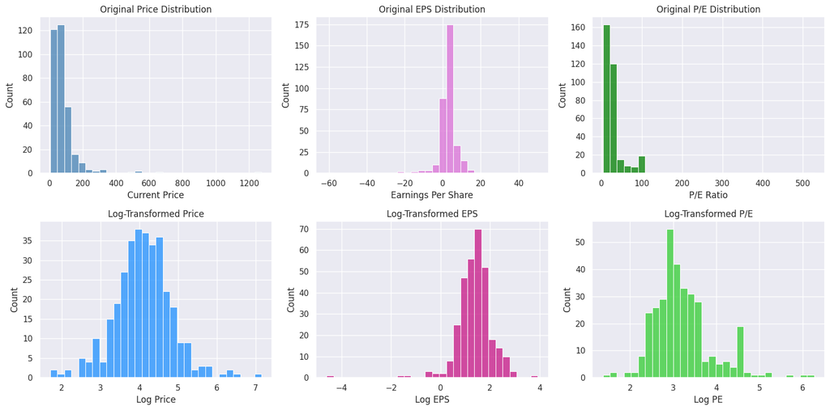

```python
# Log transformation select features to address skewness
df['Log Price'] = np.log1p(df['Current Price'])  # use log1p to avoid log(0)
df['Log EPS'] = np.log1p(df['Earnings Per Share'])
df['Log PE'] = np.log1p(df['P/E Ratio'])

# Visualize distributions before and after transformation
fig, axes = plt.subplots(2, 3, figsize=(16, 8))
sns.histplot(df['Current Price'], bins=30, ax=axes[0, 0], color='steelblue')
axes[0, 0].set_title('Original Price Distribution')

sns.histplot(df['Earnings Per Share'], bins=30, ax=axes[0, 1], color='orchid')
axes[0, 1].set_title('Original EPS Distribution')

sns.histplot(df['P/E Ratio'], bins=30, ax=axes[0, 2], color='green')
axes[0, 2].set_title('Original P/E Distribution')

sns.histplot(df['Log Price'], bins=30, ax=axes[1, 0], color='dodgerblue')
axes[1, 0].set_title('Log-Transformed Price')

sns.histplot(df['Log EPS'], bins=30, ax=axes[1, 1], color='mediumvioletred')
axes[1, 1].set_title('Log-Transformed EPS')

sns.histplot(df['Log PE'], bins=30, ax=axes[1, 2], color='limegreen')
axes[1, 2].set_title('Log-Transformed P/E')

plt.tight_layout()
plt.show()
```

Observations/Insights:

**Log Transformations for Skewed Variables**

- Log(Price), Log(EPS), Log(P/E) all produce more symmetric distributions, especially helpful for clustering and regression tasks.
- Original features were heavily right-skewed with long tails, especially P/E.
- These transformed features can now be used in models without skewing results due to outliers or extreme values.

### Feature Scaling / Normalization

Needed for clustering, PCA, or any algorithm that uses distances (K-Means, hierarchical, etc.)

- *Will use StandardScaler (Z-score): rescales to mean = 0, std = 1, good default for clustering.*
- *Will scale only Selected Features for clustering & grouping, since the goal is to group stocks and analyze the traits of each group, as they contribute to performance, valuation, risk, or size & have been cleaned and winsorized.*

```python
from sklearn.preprocessing import StandardScaler
# Select relevant features for clustering and segmentation
features_for_scaling = [
    'Current Price',
    'Price Change',
    'Volatility',
    'ROE',
    'P/E Ratio',
    'Earnings Per Share',
    'Market Cap',
    'Valuation Score'
]
# Ensure 'Market Cap' and 'Valuation Score' are in df_winsorized
df_winsorized[['Market Cap', 'Valuation Score']] = df[['Market Cap', 'Valuation Score']] # Adding the new features to df_winsorized

# Initialize StandardScaler
scaler = StandardScaler()

# Fit and transform the selected features
scaled_features = scaler.fit_transform(df_winsorized[features_for_scaling])

# Create a DataFrame for the scaled features
scaled_df = pd.DataFrame(scaled_features, columns=[f'{col}_scaled' for col in features_for_scaling])

# Merge scaled features back with original winsorized dataset
df_scaled = pd.concat([df_winsorized.reset_index(drop=True), scaled_df], axis=1)

# Display
df_scaled.head(5)
```

|  | GICS Sector | GICS Sub Industry | Current Price | Price Change | Volatility | ROE | Cash Ratio | Net Cash Flow | Net Income | Earnings Per Share | Estimated Shares Outstanding | P/E Ratio | P/B Ratio | Market Cap | Valuation Score | Current Price_scaled | Price Change_scaled | Volatility_scaled | ROE_scaled | P/E Ratio_scaled | Earnings Per Share_scaled | Market Cap_scaled | Valuation Score_scaled |
| --- | --- | --- | --- | --- | --- | --- | --- | --- | --- | --- | --- | --- | --- | --- | --- | --- | --- | --- | --- | --- | --- | --- | --- |
| 0 | Industrials | Airlines | 42.349998 | 9.999995 | 1.687151 | 135 | 51 | -604000000 | 7610000000 | 11.39 | 6.681299e+08 | 5.566284 | -8.784219 | 7.610000e+09 | -32.661253 | -0.481184 | 0.519162 | 0.290322 | 1.108348 | -0.857737 | 1.763939 | 1.599682 | 0.001656 |
| 1 | Health Care | Pharmaceuticals | 59.240002 | 8.339433 | 2.197887 | 130 | 77 | 51000000 | 5144000000 | 3.15 | 1.633016e+09 | 18.806350 | -8.750068 | 5.144000e+09 | -164.556841 | -0.255266 | 0.373377 | 1.187111 | 1.050992 | -0.405280 | 0.067163 | 0.959006 | -0.246071 |
| 2 | Health Care | Health Care Equipment | 44.910000 | 11.301121 | 1.273646 | 21 | 67 | 938000000 | 4423000000 | 2.94 | 1.504422e+09 | 15.275510 | -0.394171 | 4.423000e+09 | -6.021169 | -0.446941 | 0.633392 | -0.435741 | -0.199362 | -0.525940 | 0.023920 | 0.771688 | 0.051691 |
| 3 | Information Technology | Application Software | 93.940002 | 13.977195 | 1.357679 | 9 | 180 | -240840000 | 629551000 | 1.26 | 4.996437e+08 | 74.555557 | 4.199651 | 6.295510e+08 | 313.107326 | 0.208876 | 0.868332 | -0.288190 | -0.337015 | 1.499856 | -0.322025 | -0.213864 | 0.651079 |
| 4 | Information Technology | Semiconductors | 55.320000 | -1.827858 | 1.701169 | 14 | 272 | 315120000 | 696878000 | 0.31 | 2.247994e+09 | 178.451613 | 1.059810 | 6.968780e+08 | 189.124800 | -0.307699 | -0.519237 | 0.314936 | -0.279659 | 5.050330 | -0.517648 | -0.196373 | 0.418214 |

Observations/Insights:

```python
# Calculate mean and standard deviation of scaled features to confirm normalization
scaled_feature_columns = [
    'Current Price_scaled',
    'Price Change_scaled',
    'Volatility_scaled',
    'ROE_scaled',
    'P/E Ratio_scaled',
    'Earnings Per Share_scaled',
    'Market Cap_scaled',
    'Valuation Score_scaled'
]

# Calculate mean and standard deviation of all scaled features including engineered ones
scaled_stats = df_scaled[scaled_feature_columns].agg(['mean', 'std']).T
scaled_stats.columns = ['Mean', 'Standard Deviation']
scaled_stats
```

|  | Mean | Standard Deviation |
| --- | --- | --- |
| Current Price_scaled | 1.789418e-16 | 1.001474 |
| Price Change_scaled | -4.702121e-17 | 1.001474 |
| Volatility_scaled | -4.127417e-16 | 1.001474 |
| ROE_scaled | -3.657205e-17 | 1.001474 |
| P/E Ratio_scaled | -1.332268e-16 | 1.001474 |
| Earnings Per Share_scaled | -3.657205e-17 | 1.001474 |
| Market Cap_scaled | -3.134747e-17 | 1.001474 |
| Valuation Score_scaled | 2.089832e-17 | 1.001474 |

Observation:

- Mean and standard deviation of scaled values confirm they’re normalized correctly
- The data is clean, transformed, and ready

# Post Preprocessing EDA:

- It is a good idea to explore the data once again after manipulating it, to double ensure its readiness.

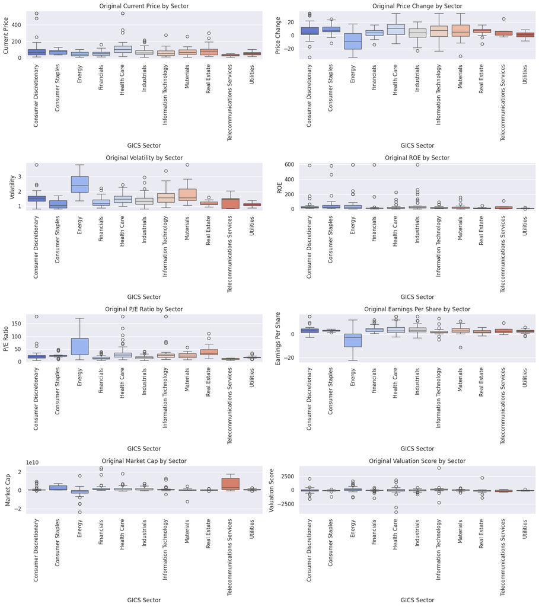

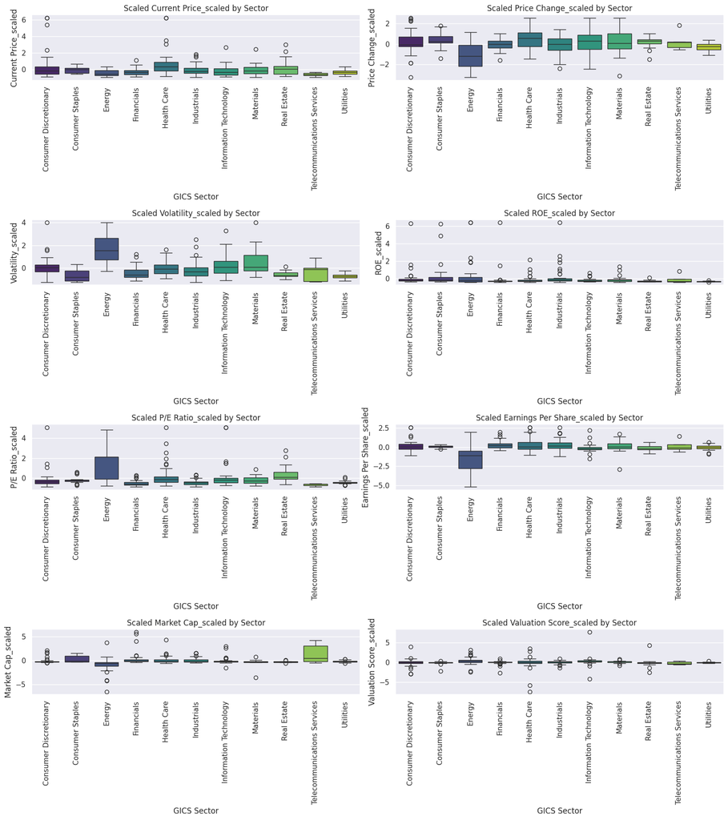

```python
# Variables of interest
original_vars = [
    'Current Price', 'Price Change', 'Volatility', 'ROE',
    'P/E Ratio', 'Earnings Per Share', 'Market Cap', 'Valuation Score'
]

scaled_vars = [f"{col}_scaled" for col in original_vars]

# Plot original variables across sectors
fig, axes = plt.subplots(4, 2, figsize=(16, 18));
axes = axes.flatten()

for idx, var in enumerate(original_vars):
    sns.boxplot(x='GICS Sector', y=var, data=df_scaled, ax=axes[idx], palette='coolwarm')
    axes[idx].set_title(f'Original {var} by Sector')
    axes[idx].tick_params(axis='x', rotation=90)

plt.tight_layout()
plt.show()

# Plot scaled variables across sectors
fig, axes = plt.subplots(4, 2, figsize=(16, 18));
axes = axes.flatten()

for idx, var in enumerate(scaled_vars):
    sns.boxplot(x='GICS Sector', y=var, data=df_scaled, ax=axes[idx], palette='viridis')
    axes[idx].set_title(f'Scaled {var} by Sector')
    axes[idx].tick_params(axis='x', rotation=90)

plt.tight_layout()
plt.show()
```

Key Observations/Insights:

**Before Scaling:**

- Market Cap, ROE, P/E Ratio, and Valuation are showing extreme ranges and outliers
- Sectors like Telecom and Energy show large variances
- Visual comparison across features is tough because each is on a wildly different scale.

**After Scaling:**

- All features are now on the same standardized scale (mean ~0, std ~1) and are easily compared across sectors

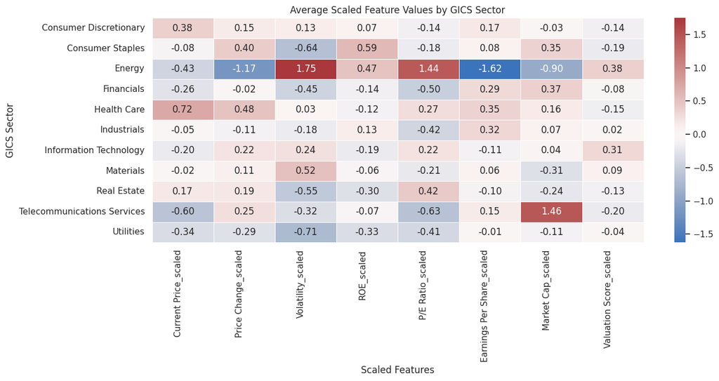

```python
# Calculate average scaled values by sector
scaled_feature_cols = scaled_df.columns.tolist()
df_scaled['GICS Sector'] = df['GICS Sector']
sector_means = df_scaled.groupby('GICS Sector')[scaled_feature_cols].mean()

# Plot heatmap
plt.figure(figsize=(14, 7));
sns.heatmap(sector_means, annot=True, cmap='vlag', center=0, linewidths=0.5, fmt=".2f")
plt.title('Average Scaled Feature Values by GICS Sector')
plt.xlabel('Scaled Features')
plt.ylabel('GICS Sector')
plt.xticks(rotation=90, ha='right')
plt.tight_layout()
plt.show()
```

Observations/Insights:

**Sectors with Above-Average Scores:**

Health Care

Consumer Discretionary

- Above average in: Current Price, Price Change, ROE
  - Indicates investor confidence and solid returns, possibly due to post-pandemic recovery trends.

Energy

- Above average in: Volatility, P/E Ratio, Valuation Score
- Below average in: Price Change, EPS
  - Sector appears overvalued and volatile but underperforming — possibly speculative or influenced by short-term market swings.

Telecommunications Services

**Sectors Performing Below Average:**

Utilities

- Below average in: ROE, Volatility, Valuation Score
  - Very stable and low-risk, but with limited growth and returns — a classic defensive sector.

Real Estate

Industrials & Materials

- Near or slightly below average across most features
  - May be in a neutral or cyclical phase, neither strongly outperforming nor underperforming.

# Principal Component Analysis (PCA):

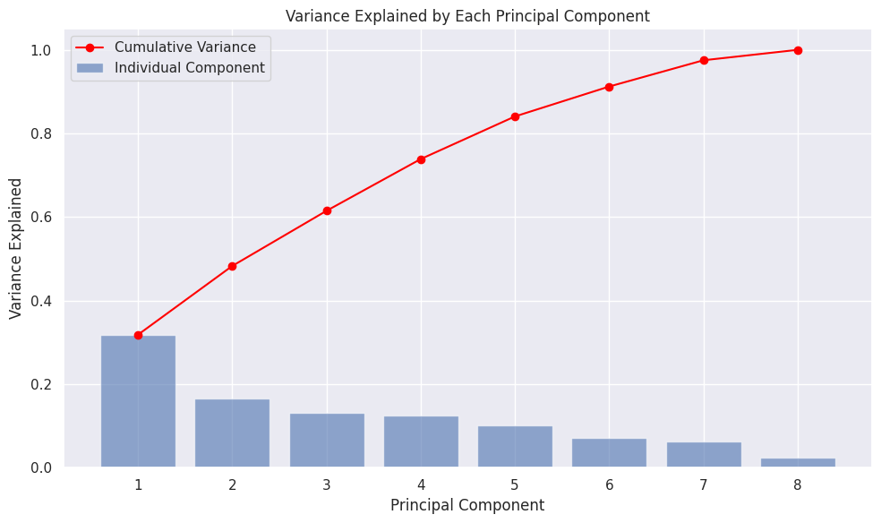

|  | Principal Component | Variance Explained | Cumulative Variance |
| --- | --- | --- | --- |
| 0 | PC1 | 0.318261 | 0.318261 |
| 1 | PC2 | 0.164515 | 0.482776 |
| 2 | PC3 | 0.131955 | 0.614731 |
| 3 | PC4 | 0.123890 | 0.738620 |
| 4 | PC5 | 0.101983 | 0.840603 |
| 5 | PC6 | 0.071581 | 0.912184 |
| 6 | PC7 | 0.062856 | 0.975040 |
| 7 | PC8 | 0.024960 | 1.000000 |

```python
# Select only the scaled features for PCA
scaled_features_for_pca = [
    'Current Price_scaled',
    'Price Change_scaled',
    'Volatility_scaled',
    'ROE_scaled',
    'P/E Ratio_scaled',
    'Earnings Per Share_scaled',
    'Market Cap_scaled',
    'Valuation Score_scaled'
]

# Perform PCA
pca = PCA()
pca_components = pca.fit_transform(df_scaled[scaled_features_for_pca])

# Create a DataFrame for PCA results
pca_df = pd.DataFrame(pca_components, columns=[f'PC{i+1}' for i in range(len(scaled_features_for_pca))])

# Add sector back to PCA DataFrame for context
pca_df['GICS Sector'] = df_scaled['GICS Sector']

# Explained variance
explained_variance = pca.explained_variance_ratio_
cumulative_variance = np.cumsum(explained_variance)

# Plot variance explained
plt.figure(figsize=(10, 6));
plt.bar(range(1, len(explained_variance)+1), explained_variance, alpha=0.6, label='Individual Component')
plt.plot(range(1, len(cumulative_variance)+1), cumulative_variance, marker='o', color='red', label='Cumulative Variance')
plt.xlabel('Principal Component')
plt.ylabel('Variance Explained')
plt.title('Variance Explained by Each Principal Component')
plt.xticks(range(1, len(explained_variance)+1))
plt.legend()
plt.grid(True)
plt.tight_layout()
plt.show()

# Show variance explained in a summary DataFrame
pca_summary = pd.DataFrame({
    'Principal Component': [f'PC{i+1}' for i in range(len(explained_variance))],
    'Variance Explained': explained_variance,
    'Cumulative Variance': cumulative_variance
})

# Display
pca_summary
```

Key Observations/Insights:

- Dimensionality Reduction Opportunity The first 5 components explain ~84% of the total variance.
  - Can therefore reduce 8 features to 5 components while preserving most of the signal. This reduces complexity while keeping the structure intact
- PC1 Is the Most Informative, it captures ~32% of the variance — likely a blend of valuation, size, and profitability features. This is the main axis of variation among stocks. *Will inspect the loadings to see what drives it.*
- PC2 and PC3 add subtle, yet important nuance
- PC2 (16.5%) and PC3 (13.2%) add non-redundant insights
- PC6 to PC8 Contribute little, these can often be dropped without much loss — they may capture noise or minor variation not meaningful to group structure

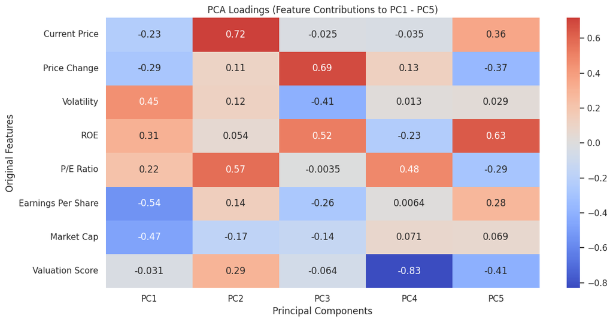

|  | PC1 | PC2 | PC3 | PC4 | PC5 |
| --- | --- | --- | --- | --- | --- |
| Current Price | -0.226876 | 0.716681 | -0.024871 | -0.034557 | 0.358896 |
| Price Change | -0.285747 | 0.106469 | 0.685782 | 0.125808 | -0.367770 |
| Volatility | 0.446634 | 0.121996 | -0.408399 | 0.013486 | 0.029469 |
| ROE | 0.311570 | 0.053724 | 0.518713 | -0.233835 | 0.634344 |
| P/E Ratio | 0.219380 | 0.568155 | -0.003508 | 0.484031 | -0.288405 |
| Earnings Per Share | -0.543995 | 0.140325 | -0.263784 | 0.006379 | 0.278164 |
| Market Cap | -0.474627 | -0.174093 | -0.139836 | 0.071374 | 0.068993 |
| Valuation Score | -0.031452 | 0.290627 | -0.063896 | -0.829877 | -0.409102 |

```python
# Calculate and visualize PCA loadings (feature contributions to each component)

# Select features and scale
features = [
    'Current Price',
    'Price Change',
    'Volatility',
    'ROE',
    'P/E Ratio',
    'Earnings Per Share',
    'Market Cap',
    'Valuation Score'
]
X_scaled = scaler.fit_transform(df[features])

# Perform PCA
from sklearn.decomposition import PCA
pca = PCA()
pca.fit(X_scaled)

# Get PCA loadings (eigenvectors)
loadings = pd.DataFrame(
    pca.components_.T,
    columns=[f'PC{i+1}' for i in range(len(features))],
    index=features
)

# Visualize top 5 component loadings
plt.figure(figsize=(12, 6));
sns.heatmap(loadings.iloc[:, :5], annot=True, cmap='coolwarm', center=0)
plt.title('PCA Loadings (Feature Contributions to PC1 - PC5)')
plt.xlabel('Principal Components')
plt.ylabel('Original Features')
plt.tight_layout()
plt.show()

loadings.iloc[:, :5]
```

Key Observations by Principal Component

PC1: Heavily influenced by Earnings Per Share (-0.54), Market Cap (-0.47), Volatility (+0.45), ROE (+0.31)

- This component seems to reflect a profitability vs. volatility and size tradeoff. Companies with high earnings and large market cap are on one end; volatile, high-ROE ones on the other.

PC2 Strongest loadings: Current Price (+0.72), P/E Ratio (+0.57), Valuation Score (+0.29)

- This PC likely represents valuation-based differentiation, with high price and high P/E companies grouped separately from low ones.

PC3 Strong contributions from: Price Change (+0.69); ROE (+0.52); Volatility (-0.41)

- PC3 seems to capture performance momentum vs. volatility. Stocks with recent price surges and strong ROE but lower volatility sit on one side of this axis.

PC4 Dominated by: Valuation Score (-0.83), P/E Ratio (+0.48),

- PC4 is a valuation quality axis, likely contrasting fundamental valuation metrics (like a composite score) with forward-looking P/E ratios.

PC5 Key features: ROE (+0.63), Current Price (+0.36), Valuation Score (-0.41)

- This component blends return on equity and pricing effects with some valuation considerations. High-ROE, high-price stocks fall on the positive side

Insights:

- PCA is effectively separating valuation, performance, and profitability patterns.
- Valuation Score loads strongly only on PC4 & PC5, meaning it's capturing a distinct angle compared to raw price or earnings.
- Price Change and ROE are consistently influential, suggesting their importance in distinguishing market behavior.
- Volatility appears inversely related to profitability (PC1, PC3), which aligns with risk-return theory.

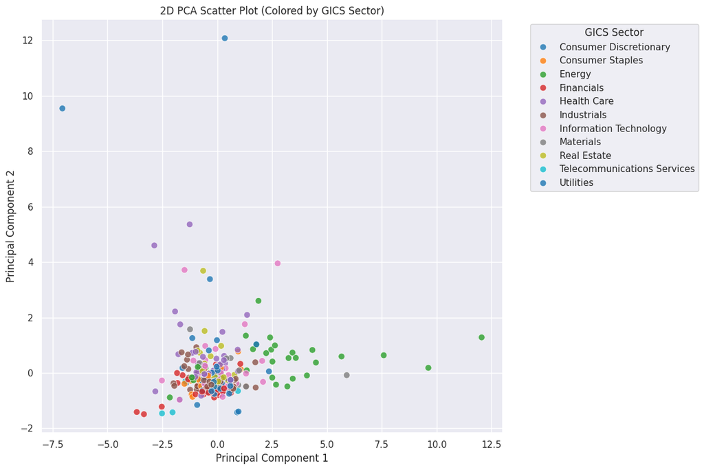

```python
# Visualizing a 2D PCA plot

# Using first two principal components from previously computed PCA
pca_2d = pd.DataFrame(pca.transform(X_scaled)[:, :2], columns=["PC1", "PC2"])

# Add sector labels for coloring
pca_2d['GICS Sector'] = df['GICS Sector']

# Plot 2D PCA scatter
plt.figure(figsize=(12, 8));
sns.scatterplot(data=pca_2d, x="PC1", y="PC2", hue="GICS Sector", palette="tab10", s=60, alpha=0.8)
plt.title("2D PCA Scatter Plot (Colored by GICS Sector)")
plt.xlabel("Principal Component 1")
plt.ylabel("Principal Component 2")
plt.legend(title="GICS Sector", bbox_to_anchor=(1.05, 1), loc='upper left')
plt.grid(True)
plt.tight_layout()
plt.show()
```

Observations/Insights:

**Clusters & Spread**

- Most stocks are concentrated near the center, indicating that the first two PCs normalize well for most companies.
- Some outliers (right side of PC1) likely represent:
  - Speculative or highly-valued stocks (based on earlier PCA loadings)
  - Possibly from Energy or Tech sectors given their volatility or high P/E profiles.

**Sector Patterns:**

- Energy & IT show more spread, consistent with risk and valuation extremes.
- Consumer Staples, Utilities, and Real Estate are more tightly clustered, suggesting homogeneous financial profiles within these sectors.
- Telecoms and Health Care display some separation.

# K-means Clustering

```python
# Using first 4 PCA components for clustering
# Perform PCA with top 4 components
pca = PCA(n_components=4)  # Explicitly set the desired number of components (4 in this case)
X_pca = pca.fit_transform(df_scaled[scaled_features_for_pca])
X_pca_4d = X_pca[:, :4]

# Re-evaluate silhouette scores for 2–10 clusters using 4 components
silhouette_scores_4d = {}
for k in range(2, 11):
    kmeans = KMeans(n_clusters=k, n_init=10, random_state=1)
    labels = kmeans.fit_predict(X_pca_4d)
    silhouette_scores_4d[k] = silhouette_score(X_pca_4d, labels)

# Choose best k for 4D clustering
best_k_4d = max(silhouette_scores_4d, key=silhouette_scores_4d.get)

# Final KMeans clustering with best k on 4 components
kmeans_final_4d = KMeans(n_clusters=best_k_4d, n_init=10, random_state=1)
df['Cluster_4D'] = kmeans_final_4d.fit_predict(X_pca_4d)

# Output silhouette scores and best k
silhouette_scores_4d, best_k_4d
```

```
({2: 0.5944266159096003,
  3: 0.6086823638295895,
  4: 0.5960130920487243,
  5: 0.6028485794671383,
  6: 0.2628228072806098,
  7: 0.2852160424003449,
  8: 0.2604466770402935,
  9: 0.2650952587742226,
  10: 0.26586626697505694},
 3)
```

Observations/Insights:

### Cluster Quality Evaluation (k=3):

1. Silhouette Plot: Statistical goodness-of-fit
2. 3D PCA Plot: Visual cluster separation

```python
from mpl_toolkits.mplot3d import Axes3D # enables 3D plotting in Matplotlib.

# Define function
def run_kmeans_with_silhouette(X, k):
    """Fit KMeans and return labels, silhouette values and average score."""
    model = KMeans(n_clusters=k, n_init=10, random_state=1)
    labels = model.fit_predict(X)
    sil_vals = silhouette_samples(X, labels)
    avg_score = silhouette_score(X, labels)
    return labels, sil_vals, avg_score

def prepare_pca_3d_df(X, labels):
    """Create a DataFrame with the first 3 principal components and cluster labels."""
    df = pd.DataFrame(X[:, :3], columns=["PC1", "PC2", "PC3"])
    df["Cluster"] = labels
    return df

def plot_silhouette(ax, silhouette_vals, labels, avg_score, k):
    """Plot silhouette chart on the given axis."""
    y_lower = 10
    for i in range(k):
        cluster_vals = silhouette_vals[labels == i]
        cluster_vals.sort()
        size_i = cluster_vals.shape[0]
        y_upper = y_lower + size_i
        ax.fill_betweenx(np.arange(y_lower, y_upper), 0, cluster_vals, label=f"Cluster {i}")
        y_lower = y_upper + 10

    ax.axvline(avg_score, color='red', linestyle='--', label="Avg silhouette")
    ax.set_title(f"Silhouette Plot (k={k})")
    ax.set_xlabel("Silhouette Coefficient")
    ax.set_ylabel("Samples")
    ax.legend()

def plot_pca_3d(ax, df, k):
    """Plot 3D PCA cluster plot on the given 3D axis."""
    for i in range(k):
        group = df[df["Cluster"] == i]
        ax.scatter(group['PC1'], group['PC2'], group['PC3'], label=f"Cluster {i}", s=40)
    ax.set_title(f"3D PCA Cluster Plot (k={k})")
    ax.set_xlabel("PC1")
    ax.set_ylabel("PC2")
    ax.set_zlabel("PC3")
    ax.legend()
```

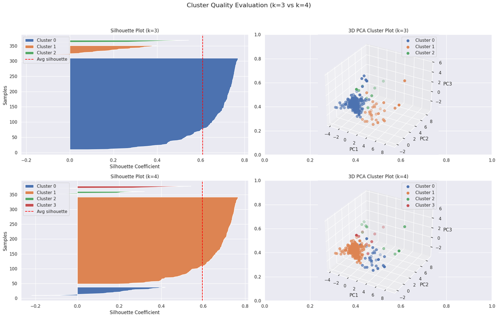

```python
# Reduce data to 4 principal components
pca = PCA(n_components=4)
X_pca_4d = pca.fit_transform(df_scaled[scaled_features_for_pca])

# Cluster evaluation and plotting for k=3 and k=4
cluster_results = {}
fig, axes = plt.subplots(2, 2, figsize=(18, 12))
fig.suptitle("Cluster Quality Evaluation (k=3 vs k=4)", fontsize=16)

for idx, k in enumerate([3, 4]):
    labels, sil_vals, avg_score = run_kmeans_with_silhouette(X_pca_4d, k)
    pca_df = prepare_pca_3d_df(X_pca_4d, labels)

    # Store for later use (optional)
    cluster_results[k] = {
        "labels": labels,
        "silhouette_vals": sil_vals,
        "avg_score": avg_score,
        "pca_df": pca_df
    }

    # Plot silhouette
    plot_silhouette(axes[idx][0], sil_vals, labels, avg_score, k)

    # Plot 3D PCA
    ax3d = fig.add_subplot(2, 2, 2 * idx + 2, projection='3d')
    plot_pca_3d(ax3d, pca_df, k)

plt.tight_layout(rect=[0, 0.03, 1, 0.95])
plt.show()
```

Key Observations/Insights:

**Silhouette Score Comparison (Statistical Fit)**

**3D PCA Visualization (Visual Separation):**

k=3:

- Cluster 0 occupies a dense and dominant region.
- Cluster 1 and 2 show mild to moderate separation.
- Some overlapping between clusters is visible, suggesting a lack of granularity.

k=4:

- Clusters are better separated visually.
- Cluster 3 (the new group) identifies a small but distinctive subgroup that wasn’t captured before.
- Provides better discrimination of edge cases or outliers.

**k=4 is the better choice overall, bearing in mind the goal to analyze the data, grouping the stocks based on the attributes provided, and sharing insights about the characteristics of each group, despite a tiny drop in average silhouette score.**

### 3. Cluster Profiling:

```python
# Assign the cluster labels (for k=4) to the 'Cluster_4D' column in the DataFrame
df['Cluster_4D'] = cluster_results[4]['labels']

# Create engineered features in 'data' DataFrame as well
df['Market Cap'] = df['Earnings Per Share'] * df['Estimated Shares Outstanding']
df['Valuation Score'] = df['P/E Ratio'] * df['P/B Ratio']

# Use existing cluster labels from k=4 results
df['Cluster_4_Label'] = df['Cluster_4D'].map({
    0: 'Established Value Leaders',
    1: 'High-Growth Market Leaders',
    2: 'Volatile or Undervalued Securities',
    3: 'Nonconforming / Atypical Profiles'
})

# Define financial features for profiling
features_to_profile = [
    'Current Price', 'Price Change', 'Volatility', 'ROE',
    'P/E Ratio', 'Earnings Per Share', 'Market Cap', 'Valuation Score'
]

# Compute mean profile per cluster
cluster_4_profile = df.groupby('Cluster_4_Label')[features_to_profile].mean().round(2)

# Display
cluster_4_profile

# Show updated dataset with new label column added
df_labeled = df[['GICS Sector', 'Cluster_4D', 'Cluster_4_Label'] + features_to_profile]
df_labeled.head(10)
```

|  | GICS Sector | Cluster_4D | Cluster_4_Label | Current Price | Price Change | Volatility | ROE | P/E Ratio | Earnings Per Share | Market Cap | Valuation Score |
| --- | --- | --- | --- | --- | --- | --- | --- | --- | --- | --- | --- |
| 0 | Industrials | 1 | High-Growth Market Leaders | 42.349998 | 9.999995 | 1.687151 | 135 | 3.718174 | 11.39 | 7.610000e+09 | -32.661253 |
| 1 | Health Care | 1 | High-Growth Market Leaders | 59.240002 | 8.339433 | 2.197887 | 130 | 18.806350 | 3.15 | 5.144000e+09 | -164.556841 |
| 2 | Health Care | 1 | High-Growth Market Leaders | 44.910000 | 11.301121 | 1.273646 | 21 | 15.275510 | 2.94 | 4.423000e+09 | -6.021169 |
| 3 | Information Technology | 1 | High-Growth Market Leaders | 93.940002 | 13.977195 | 1.357679 | 9 | 74.555557 | 1.26 | 6.295510e+08 | 313.107326 |
| 4 | Information Technology | 0 | Established Value Leaders | 55.320000 | -1.827858 | 1.701169 | 14 | 178.451613 | 0.31 | 6.968780e+08 | 189.124800 |
| 5 | Consumer Staples | 1 | High-Growth Market Leaders | 36.680000 | -12.017268 | 1.516493 | 10 | 12.267559 | 2.99 | 1.849000e+09 | 91.967810 |
| 6 | Information Technology | 3 | Nonconforming / Atypical Profiles | 276.570007 | 6.189286 | 1.116976 | 30 | 31.040405 | 8.91 | 5.965410e+08 | 4006.216980 |
| 7 | Utilities | 1 | High-Growth Market Leaders | 43.230000 | 2.174424 | 1.124186 | 9 | 16.626923 | 2.60 | 6.360000e+08 | -11.963019 |
| 8 | Utilities | 1 | High-Growth Market Leaders | 58.270000 | 2.371753 | 1.068485 | 11 | 18.456543 | 3.13 | 1.320540e+09 | -55.787649 |
| 9 | Financials | 1 | High-Growth Market Leaders | 59.900002 | 3.027181 | 1.048295 | 14 | 10.187075 | 5.88 | 2.533000e+09 | -19.191553 |

Observations/Insights:

- Observed clusters and labels

The financial profile of each k=4 cluster, labeled for easier interpretation are:

- Established Value Leaders: Stocks with moderate prices, steady returns, low volatility, and average P/E ratios — generally representing financially stable companies.
- High-Growth Market Leaders: Higher earnings per share and strong market cap but still well-balanced in other financial metrics.
- Volatile or Undervalued Securities: Moderate fundamentals but more variability, likely with higher risk and lower returns.
- Nonconforming / Atypical Profiles: Extreme valuation scores or earnings behavior — may include atypical or mispriced stocks.

### Cluster Visualization (Mean Financial Traits & Cluster Distribution):

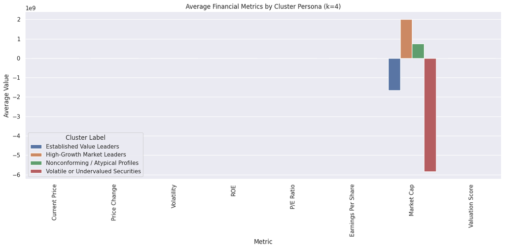

```python
# Average Financial Metrics by Cluster Persona (k=4)

# Recreate engineered features using the original copy 'data' DataFrame
df['Market Cap'] = df['Earnings Per Share'] * df['Estimated Shares Outstanding']
df['Valuation Score'] = df['P/E Ratio'] * df['P/B Ratio']

# Cluster-wise average financial metrics
profile_df = df.groupby('Cluster_4_Label')[features_to_profile].mean().round(2)

# Melt for plotting
profile_melted = profile_df.reset_index().melt(
    id_vars='Cluster_4_Label',
    var_name='Metric',
    value_name='Average Value'
)

# Plot
plt.figure(figsize=(14, 7));
sns.barplot(data=profile_melted, x='Metric', y='Average Value', hue='Cluster_4_Label')
plt.title("Average Financial Metrics by Cluster Persona (k=4)")
plt.xticks(rotation=45)
plt.legend(title='Cluster Label')
plt.xticks(rotation=90)
plt.tight_layout()
plt.show()
```

Key Observations/Insights (how the mean values of key financial metrics differ across the four clusters):

Established Value Leaders

High-Growth Market Leaders

- Strong financials across the board.
- High Current Price, EPS, and ROE.
- Elevated P/E Ratios—typical for growth stocks with future earnings potential.
- Positive Market Cap, confirming solid market valuation.
  - These are premium stocks—dominant players in their sectors with strong investor confidence.

Nonconforming / Atypical Profiles

- Financial outliers.
- Highest P/E Ratios, moderate to high volatility.
- EPS is strong but likely not aligned with valuation—suggesting hype-driven pricing.
  - These may be early-stage disruptors or overvalued assets. They're nontraditional and risky, possibly benefiting from speculation or narrative-driven markets.

Volatile or Undervalued Securities

- Financially unstable or undervalued.
- Negative Valuation Score and Market Cap (likely due to negative EPS).
- Low or negative EPS, high volatility, and poor ROE.
  - These may be distressed stocks, penny stocks, or firms with operational troubles. They're volatile and pose higher risk.

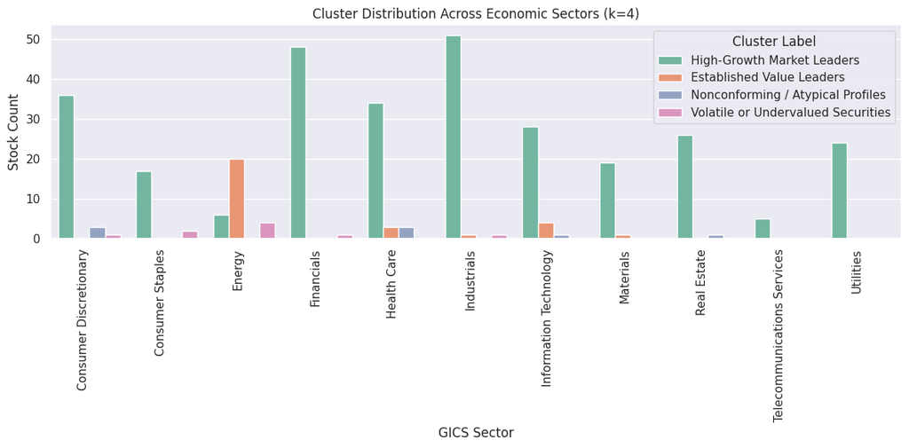

```python
# Cluster Distribution Across Economic Sectors (k=4)

# Visualize how each cluster (persona) differs in terms of average financial metrics
# Add cluster labels as string for better legend formatting
# Assign meaningful labels
cluster_descriptions = {
    0: 'Established Value Leaders',
    1: 'High-Growth Market Leaders',
    2: 'Volatile or Undervalued Securities',
    3: 'Nonconforming / Atypical Profiles'
}

# Apply cluster labels to `data` dataframe
df['Cluster_4_Label'] = df['Cluster_4D'].map(cluster_descriptions)

# Plot cluster distribution across GICS Sector (using updated data DataFrame)
plt.figure(figsize=(12, 6));
sns.countplot(data=df, x='GICS Sector', hue='Cluster_4_Label', palette='Set2')
plt.title("Cluster Distribution Across Economic Sectors (k=4)")
plt.xticks(rotation=45, ha='right')
plt.ylabel("Stock Count")
plt.xlabel("GICS Sector")
plt.legend(title="Cluster Label")
plt.xticks(rotation=90)
plt.tight_layout()
plt.show()
```

Key Observations/Insights (how each cluster is distributed by sector):

### Elbow Method Analysis: Determing K

- This visualizes the inertia (within-cluster sum of squares) across values of k from 1 to 10 — helping identify where adding more clusters offers diminishing returns.

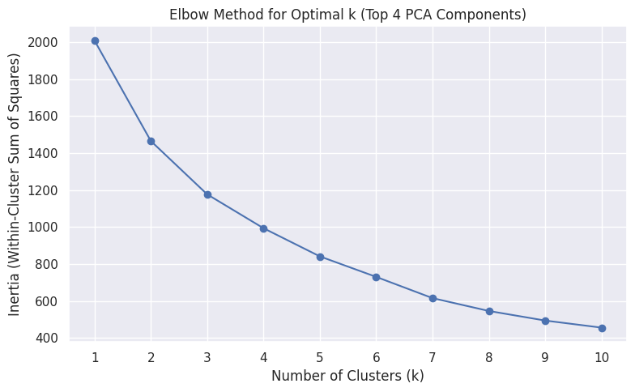

```python
# Use PCA-transformed 4D data
X_pca_4d = X_pca[:, :4]

# Calculate within-cluster sum of squares (inertia) for k = 1 to 10
inertia_scores = []
k_values = range(1, 11)

for k in k_values:
    kmeans = KMeans(n_clusters=k, n_init=10, random_state=1)
    kmeans.fit(X_pca_4d)
    inertia_scores.append(kmeans.inertia_)

# Plot the elbow curve
plt.figure(figsize=(8, 5));
plt.plot(k_values, inertia_scores, marker='o')
plt.xlabel('Number of Clusters (k)')
plt.ylabel('Inertia (Within-Cluster Sum of Squares)')
plt.title('Elbow Method for Optimal k (Top 4 PCA Components)')
plt.xticks(k_values)
plt.grid(True)
plt.tight_layout()
plt.show()
```

Observations where k is:

**The "elbow" point is at k = 4**

This is the ideal trade-off between model simplicity, separation clarity

# Hierarchical Clustering

### Distance Matrix Linkage & Dendrogram Visualization:

```python
# Define function
def plot_linkage_dendrograms(X, methods, metric='euclidean', figsize=(18, 10)):
    """
    Plots dendrograms for multiple linkage methods using hierarchical clustering.

    Args:
        X (array): Data to cluster (e.g., PCA-reduced data)
        methods (list): List of linkage methods (e.g., ['ward', 'average', ...])
        metric (str): Distance metric to use (default: 'euclidean')
        figsize (tuple): Size of the plot figure
    """
    fig, axes = plt.subplots(2, 2, figsize=figsize)
    axes = axes.flatten()

    for ax, method in zip(axes, methods):
        Z = linkage(X, method=method, metric=metric)
        dendrogram(Z, ax=ax, no_labels=True)
        ax.set_title(f"Linkage: {method.capitalize()} | Distance: {metric.capitalize()}")
        ax.set_xlabel("Samples")
        ax.set_ylabel("Distance")

    plt.tight_layout()
    plt.show()
```

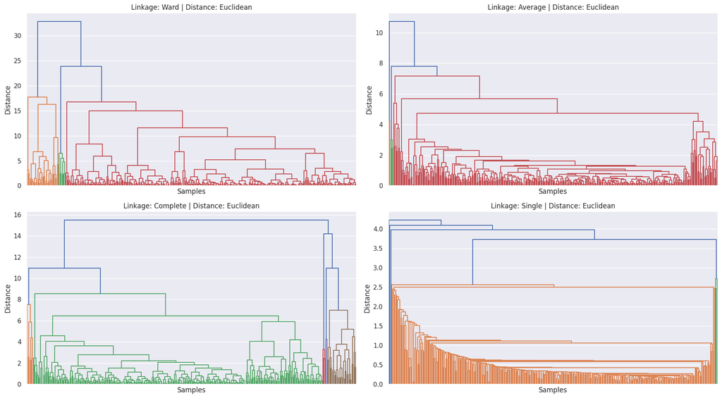

```python
# Linkage methods to compare with euclidean distance, Plot dendrograms side by side
linkage_methods = ['ward', 'average', 'complete', 'single']
plot_linkage_dendrograms(X_pca_4d, linkage_methods)
```

Key Observations/Insights:

**Ward Linkage (Best fit for this PCAdata):**

- Clear, distinct vertical jumps in distance between cluster merges.
- Indicates compact, spherical clusters that are quite separated.
- This method minimizes total within-cluster variance.
  - Best suited for identifying globular, evenly sized clusters.
  - Visually, ~3–5 clusters seem plausible by horizontal cut around distance ≈ 10–15.

**Average Linkage**

- Gradual and smoother merges.
- Less dramatic jump in height compared to Ward.
- More elongated cluster structure possible.
  - Average linkage is more sensitive to chaining effects and works well with non-globular clusters.
  - Good for balanced clustering, but less sharp distinction than Ward.

**Complete Linkage**

- Tall vertical distances, especially at the final merges.
- Prioritizes tight clusters with small maximum pairwise distances.
  - Produces compact clusters, more resistant to outliers than average linkage.
  - Can sometimes split large, naturally cohesive clusters due to sensitivity to extremes.

**Single Linkage**

- Characterized by “chaining” effect — small, incremental distance merges.
- No strong vertical distance jumps (no natural big clusters).
- Final merges happen at low distances.
  - Tends to create long, stretched clusters.
  - Poor at detecting spherical clusters
  - Useful if you want to detect clusters with irregular shapes, but very sensitive to noise.

### Silhouette Scores Validation:

```python
# Define function
def compute_silhouette_scores(X, linkage_methods, n_clusters=4, metric='euclidean'):
    """
    Computes silhouette scores for multiple linkage methods using Agglomerative Clustering.

    Args:
        X (array): Input data (e.g., PCA-reduced)
        linkage_methods (list): List of linkage strategies to evaluate
        n_clusters (int): Number of clusters
        metric (str): Distance metric

    Returns:
        pd.DataFrame: Linkage methods and corresponding silhouette scores or error messages
    """
    results = []
    for method in linkage_methods:
        try:
            model = AgglomerativeClustering(n_clusters=n_clusters, linkage=method, affinity=metric)
            labels = model.fit_predict(X)
            score = silhouette_score(X, labels)
            results.append((method, score))
        except Exception as e:
            results.append((method, f"Error: {e}"))

    return pd.DataFrame(results, columns=["Linkage Method", "Silhouette Score"])
```

```python
# Evaluate silhouette scores for each linkage method (using euclidean distance)
linkage_methods = ['ward', 'average', 'complete', 'single']
silhouette_df = compute_silhouette_scores(X_pca_4d, linkage_methods)

# Display result
silhouette_df
```

|  | Linkage Method | Silhouette Score |
| --- | --- | --- |
| 0 | ward | 0.607315 |
| 1 | average | 0.662101 |
| 2 | complete | 0.547618 |
| 3 | single | 0.666372 |

Observations/Insight:

- Single linkage has the highest silhouette score (0.666), but it often results in elongated or chaining clusters, which may not be meaningful.
- Average linkage (score 0.662) is nearly as good and more stable visually, making it the recommended choice.

### Choosing the best combination, Cut dendrogram & assign cluster labels:

```python
# Apply Agglomerative Clustering with best-performing linkage method ('average') and k=4
agg_cluster_best = AgglomerativeClustering(n_clusters=4, affinity='euclidean', linkage='average')

# Instead of directly assigning to data, create a temporary Series or array:
cluster_labels = agg_cluster_best.fit_predict(X_pca_4d)

# Assign cluster labels to working dataframe
df['Cluster_Hierarchical_Best'] = cluster_labels

# Preview assigned labels
df['Cluster_Hierarchical_Best'].value_counts().sort_index()
```

|  | Cluster_Hierarchical_Best |
| --- | --- |
| 0 | 328 |
| 1 | 7 |
| 2 | 3 |
| 3 | 2 |

**dtype:** int64

Observations/Insights:

This distribution is highly imbalanced, meaning that:

- Cluster 0 is dominant, covering nearly the entire dataset.
- The other clusters are very small (2–7 records), which suggests poor separation.
- This limits analytical insights because the smaller groups might just be outliers or noise, for balanced personas or diverse group comparisons, this is not ideal.

*Will try a different linkage..*

```python
# Fit Agglomerative Clustering using Ward linkage
agg_cluster_ward = AgglomerativeClustering(n_clusters=4, affinity='euclidean', linkage='ward')
ward_labels = agg_cluster_ward.fit_predict(X_pca_4d)

# Assign labels to the main dataframe
df['Cluster_Hierarchical_Ward'] = ward_labels

# Preview assigned labels
df['Cluster_Hierarchical_Ward'].value_counts().sort_index()
```

|  | Cluster_Hierarchical_Ward |
| --- | --- |
| 0 | 300 |
| 1 | 30 |
| 2 | 7 |
| 3 | 3 |

**dtype:** int64

Observations:

- Cluster 0: 300 stocks — this large group suggests a dominant market persona (e.g., Stable Core).
- Cluster 1: 30 stocks — still a substantial subgroup, possibly Speculative or Growth-focused.
- Cluster 2: 7 stocks — small niche, could be Premium/Outliers.
- Cluster 3: 3 stocks — likely true outliers or edge cases.

**This Ward linkage output provides better differentiation across clusters. More room for insightful profiling. Balanced silhouette score previously noted(~0.607).**

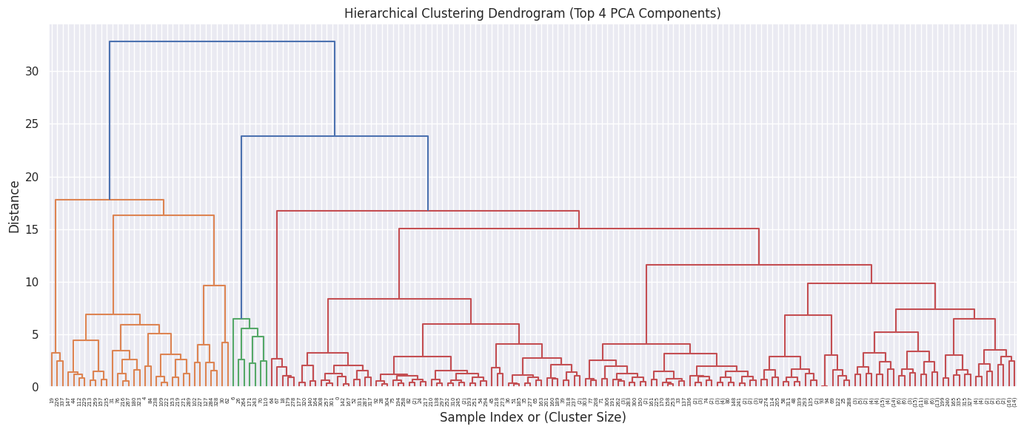

```python
# Compute linkage matrix using Ward method
Z_ward = linkage(X_pca_4d, method='ward', metric='euclidean')

# Cut dendrogram at distance threshold to get cluster labels
distance_threshold = 12
cluster_labels = fcluster(Z_ward, t=distance_threshold, criterion='distance')

# Plot Dendogram
plt.figure(figsize=(14, 6));
dendrogram(Z_ward, truncate_mode='level', p=10)
plt.title("Hierarchical Clustering Dendrogram (Top 4 PCA Components)")
plt.xlabel("Sample Index or (Cluster Size)")
plt.ylabel("Distance")
plt.tight_layout()
```

Key Observations/Insights:

Cluster Separation -

Vertical Line Heights -

Color-coded Clusters -

- The dendrogram's colored branches (under the threshold) reflect distinct groupings.
- Within each color/cluster: The branches are relatively short, implying tight intra-cluster similarity.
- Between colors: Branches diverge significantly, indicating strong inter-cluster separation.

### Determine Optimal Number of Clusters and Assign Cluster Labels:

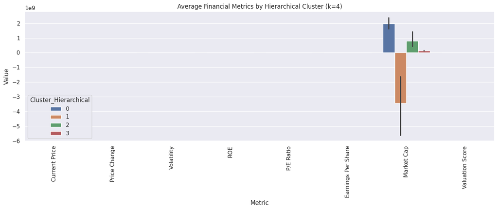

| Cluster_Hierarchical | Current Price | Price Change | Volatility | ROE | P/E Ratio | Earnings Per Share | Market Cap | Valuation Score |
| --- | --- | --- | --- | --- | --- | --- | --- | --- |
| 0 | 73.11 | 5.81 | 1.39 | 34.72 | 23.45 | 3.65 | 1.970547e+09 | -64.92 |
| 1 | 35.17 | -15.14 | 2.82 | 97.20 | 80.54 | -8.45 | -3.442751e+09 | 179.16 |
| 2 | 585.53 | 7.75 | 1.51 | 17.57 | 118.76 | 14.41 | 8.045904e+08 | 1723.20 |
| 3 | 135.91 | 14.28 | 2.01 | 3.00 | 268.82 | 0.58 | 1.378803e+08 | -3121.64 |

```python
# Perform Agglomerative Clustering with k=4 (determined from dendrogram cut)
agg_cluster = AgglomerativeClustering(n_clusters=4, affinity='euclidean', linkage='ward')
df['Cluster_Hierarchical'] = agg_cluster.fit_predict(X_pca_4d) # fit the model

# Calculate mean financial metrics for each hierarchical cluster
features_to_profile = [
    'Current Price', 'Price Change', 'Volatility', 'ROE',
    'P/E Ratio', 'Earnings Per Share', 'Market Cap', 'Valuation Score'
]
profile_hierarchical = df.groupby('Cluster_Hierarchical')[features_to_profile].mean().round(2)

# Visualization - Average Financial Metrics by Hierarchical Cluster
df_melted = df.copy()
df_melted['Cluster_Hierarchical'] = df_melted['Cluster_Hierarchical'].astype(str)
df_melted = df_melted.melt(id_vars='Cluster_Hierarchical', value_vars=features_to_profile,
                           var_name='Metric', value_name='Value')

plt.figure(figsize=(14, 6));
sns.barplot(data=df_melted, x='Metric', y='Value', hue='Cluster_Hierarchical')
plt.title('Average Financial Metrics by Hierarchical Cluster (k=4)')
plt.xticks(rotation=90)
plt.tight_layout()
plt.show()

# Display
profile_hierarchical
```

Observations/Insights:

### Assign Descriptive Labels to Cluster_Hierarchical and Analyze Sector Breakdown:

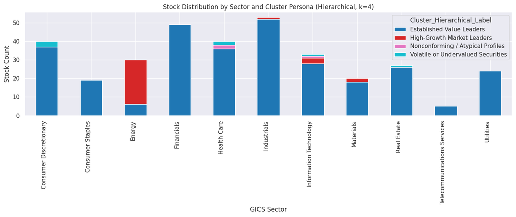

```python
# Define descriptive labels based on earlier analysis
cluster_hierarchical_labels = {
    0:  'Established Value Leaders',
    1: 'High-Growth Market Leaders',
    2: 'Volatile or Undervalued Securities',
    3: 'Nonconforming / Atypical Profiles'
}

# Assign labels to a new column in the dataframe
df['Cluster_Hierarchical_Label'] = df['Cluster_Hierarchical'].map(cluster_hierarchical_labels)

# Group by sector and cluster label to count stock distribution
sector_distribution = df.groupby(['GICS Sector', 'Cluster_Hierarchical_Label']).size().reset_index(name='Stock Count')

# Pivot for visualization
pivot_sector_dist = sector_distribution.pivot(index='GICS Sector', columns='Cluster_Hierarchical_Label', values='Stock Count').fillna(0)

# Visualize using a stacked bar chart

pivot_sector_dist.plot(kind='bar', stacked=True, figsize=(14, 6), colormap='tab10')
plt.title('Stock Distribution by Sector and Cluster Persona (Hierarchical, k=4)')
plt.ylabel('Stock Count')
plt.xlabel('GICS Sector')
plt.xticks(rotation=90, ha='right')
plt.tight_layout()
plt.show()
```

Observations/Insights:

Established Value Leaders (Dark Blue) Dominant presence across most sectors:

- Heavyweight in Industrials, Financials, Health Care, and Consumer Discretionary.
- Strong showing in Utilities and Real Estate as well.
  - This cluster consists of mature, well-established firms operating in traditionally stable sectors. They reflect broad sectoral coverage, suggesting consistent financial fundamentals across the market.

# K-means vs Hierarchical Clustering

Comparing several things, like:

- Which clustering technique took less time for execution?
- Which clustering technique gave more distinct clusters, or are they the same?
- How many observations are there in the similar clusters of both algorithms?
- How many clusters are obtained as the appropriate number of clusters from both algorithms?

Also, differences or similarities obtained in the cluster profiles from both the clustering techniques.

```python
from sklearn.metrics import confusion_matrix
import time

df_clean = df[features].dropna()

# Standardize
scaler = StandardScaler()
scaled_data = scaler.fit_transform(df_clean)

# Apply PCA
pca = PCA(n_components=4)
X_pca_4d = pca.fit_transform(scaled_data)

# Means
start_kmeans = time.time()
kmeans = KMeans(n_clusters=4, n_init=10, random_state=1)
kmeans_labels = kmeans.fit_predict(X_pca_4d)
kmeans_time = time.time() - start_kmeans
silhouette_kmeans = silhouette_score(X_pca_4d, kmeans_labels)

# Hierarchical (Ward)
start_hier = time.time()
hierarchical = AgglomerativeClustering(n_clusters=4, affinity='euclidean', linkage='ward')
hierarchical_labels = hierarchical.fit_predict(X_pca_4d)
hierarchical_time = time.time() - start_hier
silhouette_hierarchical = silhouette_score(X_pca_4d, hierarchical_labels)

# Cluster Size Comparison
kmeans_counts = pd.Series(kmeans_labels).value_counts().sort_index()
hier_counts = pd.Series(hierarchical_labels).value_counts().sort_index()

# Confusion Matrix (Overlap)
conf_matrix = confusion_matrix(kmeans_labels, hierarchical_labels)

# Add Labels to Data
df_comp = df_clean.copy()
df_comp['KMeans_Label'] = kmeans_labels
df_comp['Hierarchical_Label'] = hierarchical_labels

# Profile Each Cluster
profile_kmeans = df_comp.groupby('KMeans_Label')[features].mean().round(2)
profile_hierarchical = df_comp.groupby('Hierarchical_Label')[features].mean().round(2)

# Summary Output
summary = {
    "Execution Time (seconds)": {
        "KMeans": round(kmeans_time, 4),
        "Hierarchical": round(hierarchical_time, 4)
    },
    "Silhouette Score": {
        "KMeans": round(silhouette_kmeans, 4),
        "Hierarchical": round(silhouette_hierarchical, 4)
    },
    "KMeans Cluster Sizes": kmeans_counts.to_dict(),
    "Hierarchical Cluster Sizes": hier_counts.to_dict(),
    "Cluster Overlap (Confusion Matrix)": conf_matrix.tolist()
}

# Display profiles
print("=== KMeans Profile ===")
print(profile_kmeans, "\n")
print("=== Hierarchical Profile ===")
print(profile_hierarchical, "\n")
print("=== Comparison Summary ===")
print(summary)
```

[output not shown]

Comparison Analysis:

**Execution Time Comparison:** *This changes at every runtime*

- K-Means: 0.0223 seconds (prior run 0.0318, 0.0183, 0.0178 and so on); Hierarchical: 0.0091 seconds (prior run 0.0059, 0.0045, 0.0058 seconds, and so on...)
  - **Hierarchical clustering was faster.** This is expected with smaller datasets; hierarchical becomes more computationally expensive as data size increases.
- **However, its worthy to note that on larger datasets, KMeans is generally more scalable and efficient, while hierarchical becomes computationally heavy.**

**Clustering Quality (Silhouette Score):**

- K-Means Silhouette Score: 0.6117; Hierarchical Silhouette Score: 0.5932
  - Winner: K-Means gave slightly more well-separated clusters, making it better in terms of compactness and separation.

**Number of Observations in Similar Clusters:**

**Cluster Sizes & Balance:**

- Both identified one dominant cluster (~300 shared observations between KMeans and Hierarchical for 'Established Value Leaders) and three minor clusters, though they label them differently.

** Cluster Profile Comparison**:

K-Means Clusters:

- Established Value Leaders: Moderate price & earnings, strong ROE, stable metrics – financially solid.
- Volatile or Undervalued Securities: Negative earnings, high volatility, possible turnarounds or distressed.
- Nonconforming / Atypical Profiles: Low EPS & market cap, abnormal valuation – possible data noise or niche stocks.
- High-Growth Market Leaders: Very high price, positive EPS, high valuation – growth-driven, possibly tech-focused.

Hierarchical Clusters:

- Volatile or Undervalued Securities: Negative EPS, extreme ROE – speculative or distressed plays.
- Established Value Leaders: Moderate financials, low volatility – reliable performers.
- High-Growth Market Leaders: High price & earnings, strong valuation – likely premium tech or innovation leaders.
- Nonconforming / Atypical Profiles: Abnormally high ROE or outlier metrics – statistical outliers or special cases.

**Cluster Overlap Observation:**

- Established Value Leaders were consistently grouped in both algorithms.
- Minor discrepancies appear in how Volatile/Speculative stocks and Atypical Outliers are handled.
- The "High-Growth Market Leaders" group showed strong coherence in both models, albeit with slightly different boundaries.

# Visualize

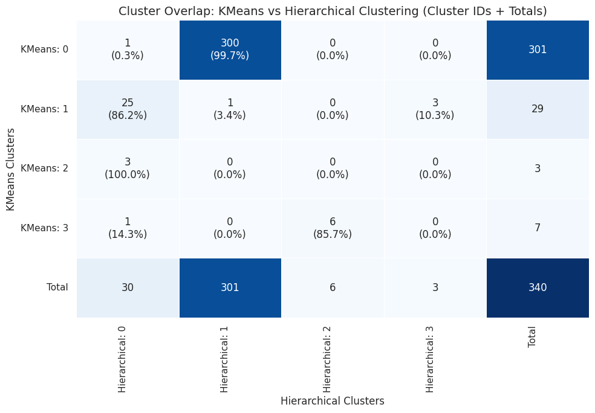

```python
# Add totals
conf_matrix_with_totals = np.zeros((conf_matrix.shape[0] + 1, conf_matrix.shape[1] + 1), dtype=int)
conf_matrix_with_totals[:-1, :-1] = conf_matrix
conf_matrix_with_totals[-1, :-1] = conf_matrix.sum(axis=0)  # column totals
conf_matrix_with_totals[:-1, -1] = conf_matrix.sum(axis=1)  # row totals
conf_matrix_with_totals[-1, -1] = conf_matrix.sum()         # grand total

# # Create index and column labels for the confusion matrix DataFrame, including 'Total' row/column
index_labels = [f'KMeans: {i}' for i in range(conf_matrix.shape[0])] + ['Total']
col_labels = [f'Hierarchical: {i}' for i in range(conf_matrix.shape[1])] + ['Total']
conf_df = pd.DataFrame(conf_matrix_with_totals, index=index_labels, columns=col_labels) # Construct a DataFrame for the confusion matrix with totals
percent_matrix = np.zeros_like(conf_matrix_with_totals, dtype=float) # Create annotation matrix with count and percentage

# Safely compute row-wise percentages, ignoring divide-by-zero errors
with np.errstate(divide='ignore', invalid='ignore'):
    percent_matrix[:-1, :-1] = (conf_matrix / conf_matrix.sum(axis=1, keepdims=True)) * 100
    percent_matrix[np.isnan(percent_matrix)] = 0  # Replace NaNs (from 0/0) with 0

# Create an annotation matrix combining counts and percentages (formatted for display)
annot = np.empty_like(conf_matrix_with_totals).astype(str)

# Fill annotation matrix
for i in range(conf_matrix_with_totals.shape[0]):
    for j in range(conf_matrix_with_totals.shape[1]):
        count = conf_matrix_with_totals[i, j]
        if i < conf_matrix.shape[0] and j < conf_matrix.shape[1]:
            # Annotate with count and percentage for core matrix
            percent = percent_matrix[i, j]
            annot[i, j] = f"{count}\n({percent:.1f}%)"
        else:
            annot[i, j] = f"{count}" # For totals (last row/col), just display the count

# Plot the heatmap
plt.figure(figsize=(10, 7));
sns.heatmap(conf_df, annot=annot, fmt='', cmap='Blues', cbar=False, linewidths=0.5)

plt.title("Cluster Overlap: KMeans vs Hierarchical Clustering (Cluster IDs + Totals)", fontsize=14)
plt.xlabel("Hierarchical Clusters", fontsize=12)
plt.ylabel("KMeans Clusters", fontsize=12)
plt.xticks(rotation=90, ha='right')
plt.yticks(rotation=0)
plt.tight_layout()
plt.show()
```

Key Observations/Insights:

## Actionable Insights and Recommendations for Trade & Ahead

To enable personalized, data-driven investment strategies, KMeans clustering was applied (using 4 PCA components for dimensionality reduction) to group stocks into meaningful financial segments. These clusters provide a scalable and consistent way to categorize stocks based on risk, growth potential, and valuation.

### Integration Opportunities:

- **Embed cluster labels** directly into Trade & Ahead’s stock analysis dashboard or screening tool for enhanced client visibility.
- **Refresh clustering quarterly** to adapt to evolving market conditions and maintain portfolio relevance.

### Business Value:

By aligning stock recommendations to cluster characteristics, Trade & Ahead can:

- Personalize investment strategies to client risk profiles
- Streamline portfolio design using interpretable financial segments
- Add predictive intelligence to traditional advisory workflows

**Bottom Line:** Clustering supports scalable, insight-driven advisory—empowering Trade & Ahead to deepen client engagement while staying ahead of market shifts.

# Conclusion:

This project, unsupervised learning techniques (KMeans and Hierarchical Clustering) were applied to segment a diverse set of publicly listed companies based on their financial and market performance metrics.

Through dimensionality reduction, careful preprocessing, and cluster evaluation using Elbow and Silhouette methods, identified meaningful stock groupings with distinct investment profiles. The clustering framework revealed insights into volatility, profitability, and valuation patterns across sectors, allowing to profile clusters as Value Leaders, Growth Leaders, or High-Risk Speculatives.

These insights, when embedded into Trade & Ahead’s advisory ecosystem, can significantly enhance client-facing tools, enabling personalized, risk-aligned investment strategies. Beyond technical rigor, the project demonstrates the strategic value of machine learning in driving modern financial decision-making.

As market conditions evolve, this clustering framework can be continuously refined, making it a dynamic engine for informed and adaptive portfolio guidance.

# Appendix A: Detailed Exploratory Data Analysis (EDA)

## Univariate Analysis:

```python
# Function to plot a boxplot and a histogram along the same scale.


def histogram_boxplot(data, feature, figsize=(12, 7), kde=False, bins=None):
    """
    Boxplot and histogram combined

    data: dataframe
    feature: dataframe column
    figsize: size of figure (default (12,7))
    kde: whether to the show density curve (default False)
    bins: number of bins for histogram (default None)
    """
    f2, (ax_box2, ax_hist2) = plt.subplots(
        nrows=2,  # Number of rows of the subplot grid= 2
        sharex=True,  # x-axis will be shared among all subplots
        gridspec_kw={"height_ratios": (0.25, 0.75)},
        figsize=figsize,
    )  # creating the 2 subplots
    sns.boxplot(
        data=data, x=feature, ax=ax_box2, showmeans=True, color="violet"
    )  # boxplot will be created and a star will indicate the mean value of the column
    sns.histplot(
        data=data, x=feature, kde=kde, ax=ax_hist2, bins=bins, palette="winter"
    ) if bins else sns.histplot(
        data=data, x=feature, kde=kde, ax=ax_hist2
    )  # For histogram
    ax_hist2.axvline(
        data[feature].mean(), color="green", linestyle="--"
    )  # Add mean to the histogram
    ax_hist2.axvline(
        data[feature].median(), color="black", linestyle="-"
    )  # Add median to the histogram
```

```python
# Function to create labeled barplots

def labeled_barplot(data, feature, perc=False, n=None):
    """
    Barplot with percentage at the top

    data: dataframe
    feature: dataframe column
    perc: whether to display percentages instead of count (default is False)
    n: displays the top n category levels (default is None, i.e., display all levels)
    """

    total = len(data[feature])  # length of the column
    count = data[feature].nunique()
    if n is None:
        plt.figure(figsize=(count + 1, 5))
    else:
        plt.figure(figsize=(n + 1, 5))

    ax = sns.countplot(
        data=data,
        x=feature,
        palette='viridis',
        order=data[feature].value_counts().index[:n].sort_values(),
    )

    for p in ax.patches:
        if perc == True:
            label = "{:.1f}%".format(
                100 * p.get_height() / total
            )  # percentage of each class of the category
        else:
            label = p.get_height()  # count of each level of the category

        x = p.get_x() + p.get_width() / 2  # width of the plot
        y = p.get_height()  # height of the plot

        ax.annotate(
            label,
            (x, y),
            ha="center",
            va="center",
            size=12,
            xytext=(0, 5),
            textcoords="offset points"
        )  # annotate the percentage
    plt.xticks(rotation=90)  # rotate the x-axis labels
    plt.title(f"{feature.title()} Distribution")  # plot title
    plt.show()  # show the plot
```

### Plotting all the features at one go

```python
data.columns
```

```
Index(['Ticker Symbol', 'Security', 'GICS Sector', 'GICS Sub Industry',
       'Current Price', 'Price Change', 'Volatility', 'ROE', 'Cash Ratio',
       'Net Cash Flow', 'Net Income', 'Earnings Per Share',
       'Estimated Shares Outstanding', 'P/E Ratio', 'P/B Ratio'],
      dtype='object')
```

```python
df.columns
```

```
Index(['GICS Sector', 'GICS Sub Industry', 'Current Price', 'Price Change',
       'Volatility', 'ROE', 'Cash Ratio', 'Net Cash Flow', 'Net Income',
       'Earnings Per Share', 'Estimated Shares Outstanding', 'P/E Ratio',
       'P/B Ratio', 'Market Cap', 'Valuation Score', 'Log Price', 'Log EPS',
       'Log PE', 'Cluster_4D', 'Cluster_4_Label', 'Cluster_Hierarchical_Best',
       'Cluster_Hierarchical_Ward', 'Cluster_Hierarchical',
       'Cluster_Hierarchical_Label'],
      dtype='object')
```